# FS/maxeffCons on the MD/harm DGM — MR (IJ) / MR (field) template, batchable

- Show All Code
- Hide All Code
- View Source

Continuous twin of the survival fb_mr_field template: the field block, the complement field and the joint pair on the mean-difference scale

Author

Larry F. León

Published

September 16, 2026

> **Template (TASK_continuous_field_mac_2026-09-07).** One committed file runs every cell of the continuous/MD design: each knob reads an `FS_MD_*` environment variable first and falls back to the in-file default, so an unattended driver renders `FS_MD_MD=40 FS_MD_N=500 FS_MD_CAMPAIGN=cont_field_mac quarto render <this file> --output …` without editing the template. Every resolved value is echoed below and lands in the bundle’s `meta`. The committed batch documents (`sim_fs_maxeffCons_mr_md*_batch_1_1000.qmd`) and their bundles are not touched: this document writes under its own stem token (`mr_field`) and a mandatory campaign tag, and refuses to overwrite any git-tracked bundle.

# 1 What this evaluates

Per replicate, identify $\hat H$ with forest search (`sg_focus = "maxeffCons"`) on the ACTG175 CD4-change DGM and compute, on the same data and selected subgroup, the estimators of the within-subgroup mean difference and their intervals:

- **oracle** $\hat\theta(Q)$ — refit on the true region;
- **naive** $\hat\theta(\hat H)$ — the plug-in on the selected region with its Wald interval;
- **MR (IJ)** $\tilde\theta(\hat H)$ — the two-term de-biased multiplier-resampling estimate on the fixed fitted family, with its infinitesimal-jackknife interval (the paper’s method; `ci_method = "ij"` reproduces the committed bundles);
- **MR (field)** — `ci_method = "field"`: the shrunk-field estimator `est2` and the Λ*-quantile intervals; its **one-sided lower bound** (harm claim) is the directional product on $\hat H$;
- **complement field** (`field_complement = TRUE`) — Λ*ᶜ from the same multipliers and winners; its **one-sided upper bound** (benefit claim) is the directional product on $\hat H^{c}$;
- **joint pair** — simultaneous ($\hat H$ lower, $\hat H^{c}$ upper) from the aligned draws: separate / Bonferroni / calibrated;
- **FB** — never re-run here (decision M-3): joined by `sim_id` from the committed FB bundle under `FS_MD_FB=join`, otherwise absent.

Scoring uses the exact conditional estimand $\beta(\hat H)$ on the DGM super-population (zero Monte Carlo error), $\beta(\hat H^{c})$ for the complement, the structural and fitted true-region references, and the oracle.

**Scales.** The MR gate, the oracle and the FB columns are **oriented** (positive = harm; the gate works on $-\,$`cd4_change` because `adverse_outcome = FALSE`); `betaHhat_H`/`betaHhat_Hc` and `truth$effect_*` are **raw** (negative = harm). The summary layer bridges with `.orient = -1`. Every field quantity is on the oriented MD scale: `fld_H_lo1s` is the harm-direction lower bound (“harm at least L”), `fld_Hc_up1s` the complement’s upper bound (“harm at most U”, i.e. benefit at least $-U$ raw). Bounds are read by **location against clinically meaningful MD thresholds** (stated in the bound-location tables as reading aids), never as significance at the null.

# 2 Setup — all knobs

```r
.t0_doc <- Sys.time()   # start of document wall-clock (total reported at the end)
# forestsearch must be INSTALLED (devtools::install()), not load_all(): the
# doFuture workers spawn separate R processes that only see the installed
# package.
library(forestsearch)
suppressPackageStartupMessages({
  library(doFuture); library(foreach); library(data.table)
})

# ── Environment overrides (FS_MD_*) ─────────────────────────────────────────
.env_chr <- function(k, d) { v <- Sys.getenv(k, unset = NA); if (is.na(v) || !nzchar(v)) d else v }
.env_int <- function(k, d) as.integer(.env_chr(k, d))
.env_num <- function(k, d) as.numeric(.env_chr(k, d))

# ── Parallelization topology ────────────────────────────────────────────────
# "sims": replicates fan out across workers; the search and the MR gate run
# sequentially within each replicate.  FB is never run here, so the "boots"
# topology of the twin has no use and is not offered.
parallel_mode <- "sims"
# Worker count: physical cores - 1 (decision M-4), overridable and capped there.
.phys_minus1 <- max(1L, parallel::detectCores(logical = FALSE) - 1L)
n_workers    <- min(.env_int("FS_MD_WORKERS", .phys_minus1), .phys_minus1)

# ── Counts ──────────────────────────────────────────────────────────────────
n_sims       <- .env_int("FS_MD_NSIMS", 1000L)   # replicates in THIS batch
diag_mode    <- FALSE   # TRUE caps to 5 reps and relays worker errors verbatim
nb_boots     <- NULL    # FB is NEVER run in this document (M-3); see fb_mode
mr_draws     <- 5000L   # MR multiplier draws (the committed value)
k_random_noise <- .env_int("FS_MD_KNOISE", 0L)   # k standard-normal noise confounders

# ── Batching across renders (seed-disjoint pieces; pool via combine) ────────
# Every per-replicate seed is seed_base + sim_id (DGM, search, and noise), so
# disjoint sim_id ranges across renders pool to exactly one big run.
run_mode     <- .env_chr("FS_MD_MODE", "batch")   # "batch" (run + save one piece) | "combine" (merge + report)
stopifnot(run_mode %in% c("batch", "combine"))
sim_id_start <- .env_int("FS_MD_START", 1L)
seed_base    <- 8316951L

# ── The identifier: engine + focus (these ARE the estimator; they feed the stem)
subgroup_method <- "consistency"
# Focus knob (FS_MD_FOCUS; TASK_md_field_rerun_2026-09-15 E1, transplanted
# from the survival template's FS_S7_FOCUS).  forestsearch() derives the MR
# re-selection rule from sg_focus, so the gate re-selects under the same
# functional; the stem follows focus_tag as it always has.
sg_focus        <- .env_chr("FS_MD_FOCUS", "maxeffCons")  # "maxeffCons": highest effect meeting the consistency rate
# Guard (the survival template's six-criterion set): anything else stops the render.
stopifnot(sg_focus %in% c("effMaxSG", "maxeffCons", "effMinSG", "maxSG", "minSG", "maxeff"))
.band_foci <- c("effMaxSG", "effMinSG")
# Band-width knob (FS_MD_NBHD).  effect_neighborhood is the identifier's band
# half-width (effect >= (1 - eps) * max effect among the consistency-qualifying
# candidates, on the harm-oriented MD scale), forwarded to the gate unchanged
# by forestsearch() as `nbhd`.  Read HERE, before the stem, because a
# non-default value tags the stem below.
effect_neighborhood <- .env_num("FS_MD_NBHD", 0.10)
stopifnot(is.finite(effect_neighborhood), effect_neighborhood >= 0, effect_neighborhood < 1)
# eps belongs to the band foci only.  Supplying FS_MD_NBHD with any other focus
# is an error, not a silently inert setting.  Unset, the 0.10 default is still
# forwarded (it is forestsearch()'s own default), so every committed non-band
# render is unchanged.
if (!sg_focus %in% .band_foci && nzchar(Sys.getenv("FS_MD_NBHD")))
  stop(sprintf("FS_MD_NBHD is set (%s) but sg_focus = '%s' does not consult effect_neighborhood; it is accepted only for %s.",
               Sys.getenv("FS_MD_NBHD"), sg_focus, paste(.band_foci, collapse = " / ")),
       call. = FALSE)

# ── Cell: scenario knob and sample size ─────────────────────────────────────
# FS_MD_MD = "40" | "120" | "null".  The twin calibrates k_inter to the target
# MD in the harm region (raw scale; oriented +40); "null" is the twin's
# null_cell switch (no treatment-by-subgroup interaction; target_md_harm is
# kept at the twin's value so meta matches the committed null bundle).
.md_knob       <- .env_chr("FS_MD_MD", "40")
null_cell      <- identical(tolower(.md_knob), "null")
target_md_harm <- if (isTRUE(null_cell)) -40 else -abs(as.numeric(.md_knob))
stopifnot(is.finite(target_md_harm))
n_sample       <- .env_int("FS_MD_N", 500L)
# DGM build route.  "calibrate" = calibrate_glm_interaction() to target_md_harm
# (md40); "direct" = generate_glm_dgm() at the locked k_inter from the breadth
# forecast (the committed md120 route; its calibrator cannot reach 120 on the
# [0, 120] grid).  Default follows the committed documents.
dgm_build <- .env_chr("FS_MD_BUILD", if (abs(target_md_harm) == 120) "direct" else "calibrate")
stopifnot(dgm_build %in% c("calibrate", "direct"))

method_tag <- if (identical(subgroup_method, "consistency")) "fs" else subgroup_method
# One source of truth: fs_focus_tag() holds the (subgroup_method, sg_focus)
# -> stem tag map for every driver.
focus_tag <- forestsearch::fs_focus_tag(subgroup_method, sg_focus)
if (!identical(focus_tag, sg_focus))
  cat(sprintf("NOTE: sg_focus '%s' is an alias on the %s path; output stem uses focus tag '%s'.\n",
              sg_focus, subgroup_method, focus_tag))

# TEMPLATE STEM (collision guards, as in the survival fb_mr_field template):
#   1. the token is "mr_field", so no output of this document can glob-match
#      the committed "mr_md40"/"mr_mdnull" stems of the twin;
#   2. a mandatory campaign_tag suffix namespaces every campaign (smoke vs
#      production vs any rerun), so combine_glob can never pool across them.
campaign_tag <- .env_chr("FS_MD_CAMPAIGN", "c1")
stopifnot(grepl("^[A-Za-z0-9]+$", campaign_tag))
# Band tag only when non-default, so every committed stem (mdf1 included) is
# unchanged (TASK_p30sg_nb20_2026-09-07).
nbhd_tag <- if (abs(effect_neighborhood - 0.10) < 1e-12) "" else
              sprintf("_nb%02d", round(100 * effect_neighborhood))
rds_stem <- sprintf("%s_%s_mr_field_md%02d_knoise%d_n%d%s_%s",
                    method_tag, focus_tag, abs(target_md_harm),
                    k_random_noise, n_sample, nbhd_tag, campaign_tag)
# Quick-run renders are stem-tagged so their bundle can NEVER pool with real
# batches (the tag also renames the results directory).
quickrun <- identical(.env_chr("FS_MD_QUICKRUN", "FALSE"), "TRUE")
if (isTRUE(null_cell)) rds_stem <- sub("_md[0-9]+_", "_mdnull_", rds_stem)
if (isTRUE(quickrun)) rds_stem <- paste0(rds_stem, "_quickrun")
# Results directory: the twin's layout WITHOUT its "_s<n_sims>" piece, so
# seed-disjoint batches of different sizes land in one directory and pool.
results_dir <- file.path("mr_md_harm", sprintf("%s_d%d", rds_stem, mr_draws))
if (identical(run_mode, "batch"))
  dir.create(results_dir, recursive = TRUE, showWarnings = FALSE)
sim_id_end    <- sim_id_start + n_sims - 1L
rds_path      <- file.path(results_dir, sprintf("%s_res_%d_%d.rds", rds_stem, sim_id_start, sim_id_end))
combine_glob  <- file.path(results_dir, sprintf("%s_res_*.rds", rds_stem))
combine_files <- NULL    # optional explicit character vector; NULL -> the glob
# FS_MD_SAVE_COMBINED=FALSE lets a verification combine render run every table
# WITHOUT writing the pooled bundle.
save_combined <- !identical(.env_chr("FS_MD_SAVE_COMBINED", "TRUE"), "FALSE")
combined_path <- NULL    # NULL -> "<results_dir>/<stem>_combined_<min>_<max>.rds",
                         # deliberately OUTSIDE combine_glob so a re-combine
                         # never re-ingests its own pooled output.
```

```r
# Refuse to overwrite a git-tracked bundle (committed bundles are read-only;
# ported from the survival template).  git ls-files --error-unmatch exits 1 for
# an untracked path and non-zero outside a repository; both fall through to
# "not tracked", so an untracked batch behaves exactly as before.
.refuse_if_tracked <- function(path) {
  tracked <- tryCatch(
    system2("git", c("ls-files", "--error-unmatch", shQuote(path)),
            stdout = FALSE, stderr = FALSE) == 0L,
    error = function(e) FALSE)
  if (isTRUE(tracked))
    stop("refusing to overwrite the git-tracked bundle '", path,
         "': committed bundles are read-only -- use a new campaign_tag.",
         call. = FALSE)
  invisible(path)
}

# ── Search configuration (committed MD values; resample identification) ─────
consistency_method <- "resample"
# MR's de-biasing rule is derived by forestsearch() from sg_focus — not set
# here. Override only via mr_inference_args(reselection=) (advanced use).
selection_rule      <- "neighborhood"  # band rule for effMaxSG/effMinSG arms;
# What the package already requires (.validate_selection_rule(),
# R/subgroup_consistency_helpers.R:743), checked here so it fails before any
# replicate runs rather than inside every one.
if (!identical(selection_rule, "neighborhood") && !sg_focus %in% .band_foci)
  stop(sprintf("selection_rule = '%s' is accepted only for %s; sg_focus = '%s'.",
               selection_rule, paste(.band_foci, collapse = " / "), sg_focus),
       call. = FALSE)
# effect_neighborhood: read above (FS_MD_NBHD, default 0.10 = the package
# default) next to the stem it tags; band half-width for effMaxSG/effMinSG,
# inert under sg_focus = "maxcons"/"maxeffCons".
stop_threshold      <- NULL            # pinned so the resolved setting is visible
md_threshold   <- 30    # effect.threshold, oriented scale (true clearance
                        # <=> P(Q|H) >= 27.2% — alignment doc section 2)
md_consistency <- 10    # consistency.threshold. OPEN QUESTION D2: sits below
                        # both CATE values, hence non-discriminating.
pconsistency   <- 0.90
fs_splits <- 400L; maxk <- 2L; n_min <- 60L; d0_min <- 12L; d1_min <- 12L

# ── Candidate cuts on the true-region covariates (J-quantile grids) ──────────
# The twin's design symmetry with the survival template: J-quantile grids on
# the two true-region covariates REPLACE the default cuts (which would contain
# both true boundaries exactly).  See the twin for the measured consequences.
fs_conf.cont_jcuts <- list(age = 10, preanti = 10)
use_lasso <- FALSE; use_dina <- FALSE; use_grf <- FALSE; use_twostage <- TRUE
is_rct <- TRUE; vi_grf_min <- -0.2
adverse_outcome <- FALSE   # higher CD4 change = better; harm = negative MD

# ── DGM knobs (verbatim from the committed harness; do NOT recalibrate) ─────
actg_arms        <- c(1L, 3L)
actg_treat_arm   <- 1L
actg_age_cut     <- 34
actg_preanti_cut <- 744.5
dgm_n_super <- 5000L
cal_k_grid_range <- c(0, 120); cal_grid_step <- 2
dgm_factor_vars   <- paste0("z", 1:12)
dgm_subgroup_vars <- c("z1", "z2")
dgm_subgroup_cuts <- list(z1 = 1L, z2 = 1L)
# The ANALYSIS covariates stay the raw ACTG175 variables -- NOT the DGM's
# z-factors; the search recovers the z1/z2 region through its own cuts.
analysis_continuous_vars <- c("age","preanti","wtkg","karnof","cd40","cd80")
analysis_binary_vars     <- c("hemo","homo","drugs","race","gender","symptom")
# str2: the literature's binary proxy for preanti (ON, as in every committed
# bundle; turning it off changes the candidate family).
include_str2 <- TRUE
if (isTRUE(include_str2))
  analysis_binary_vars <- c(analysis_binary_vars, "str2")
outcome_name <- "y_sim"; treat_name <- "treat_sim"
id_name <- "id"; harm_col <- "flag_harm"
`%||%` <- function(a, b) if (is.null(a) || length(a) == 0 || all(is.na(a))) b else a

# ── MR inference controls (mr_inference_args) ───────────────────────────────
# ci_method "field" computes everything the "ij" path computes -- the debiased
# element keeps the IJ interval, so the mr_* (IJ) recorder columns are
# IDENTICAL to an "ij" run -- and additionally returns the field block
# (fit$mr_inference$field), recorded below as fld_H_*.  Set FS_MD_CI=ij for the
# identity run against the committed bundles.  field_R_out/field_R_in are not
# forwarded by forestsearch(): the package defaults 1000/500 apply, as on the
# survival template.
mr_ci_method    <- .env_chr("FS_MD_CI", "field")
stopifnot(mr_ci_method %in% c("ij", "field"))
mr_t_confirm    <- NULL       # NULL -> near-null default for this measure (0 for MD)
mr_confirm_rule <- "point"
# kappa (uniform) calibration: a closed line; the knob is kept for parity and
# is off by default (FALSE leaves every output byte-identical).
mr_field_uniform <- identical(.env_chr("FS_MD_UNIFORM", "FALSE"), "TRUE")
# Complement field (default ON for this design; consulted only under "field").
mr_field_complement <- identical(.env_chr("FS_MD_FIELD_COMPLEMENT", "TRUE"), "TRUE")
# Complement-scale knob (field-s; TASK_field_studentize_e1_2026-09-08).
# DEFAULT "selected" from TASK_cert20_2026-09-08 Part D: field-s is the
# recommended complement construction, so unset = recommended; set
# FS_MD_FIELD_SCALEC=none for the prior behaviour.
mr_field_scalec <- .env_chr("FS_MD_FIELD_SCALEC", "selected")
stopifnot(mr_field_scalec %in% c("none", "selected"))
# IJ residual populating the REPORTED mr_*_se_ij / mr_*_lo / mr_*_hi;
# "two_term" keeps those columns byte-identical to the committed bundles.
mr_ij_residual <- .env_chr("FS_MD_IJ_RESIDUAL", "two_term")
stopifnot(mr_ij_residual %in% c("two_term", "winner", "winner_floor"))
# Re-selection frequencies (p-hat): add-only in the gate, after the multiplier
# stream is consumed; recorded as p_hat_H and the top-3 candidates.
mr_return_reselection <- identical(.env_chr("FS_MD_RESELECTION", "TRUE"), "TRUE")
# Winner-only / winner-floor IJ rows: rejected on theoretical grounds; excluded
# from every table and figure unless FS_MD_WINNER_ROWS=TRUE (columns stay).
show_winner_rows <- identical(.env_chr("FS_MD_WINNER_ROWS", "FALSE"), "TRUE")
mr_inference_args <- c(
  list(ci_method = mr_ci_method, draws = mr_draws, include_complement = TRUE,
       confirm_rule = mr_confirm_rule, field_uniform = mr_field_uniform,
       field_complement = mr_field_complement, ij_residual = mr_ij_residual,
       field_scale_complement = mr_field_scalec,
       return_reselection = mr_return_reselection),
  if (!is.null(mr_t_confirm)) list(t_confirm = mr_t_confirm))
```

```r
# ── FB comparator: joined, never run (decision M-3) ─────────────────────────
#   "none" -> no FB columns (all NA);
#   "join" -> read the committed FB bundle at fb_join_path and copy its fb_*
#             columns by sim_id after the run loop, licensed per replicate by
#             the naive-estimate identity; sim_ids outside it stay NA.
fb_mode <- .env_chr("FS_MD_FB", "none")
stopifnot(fb_mode %in% c("none", "join"))
fb_join_path <- .env_chr("FS_MD_FB_PATH",
  file.path("fb_mr_md_harm", "fs_maxeffCons_fb_mr_md40_knoise0_n500_s100_d5000",
            "fs_maxeffCons_fb_mr_md40_knoise0_n500_res_1_100.rds"))
# Enumerated cross-vintage selection-flip replicates to skip in the join
# (comma-separated sim_ids); none are known on the continuous path.
fb_join_skip <- local({
  v <- .env_chr("FS_MD_JOIN_SKIP", "")
  if (nzchar(v)) sort(unique(as.integer(strsplit(v, ",", fixed = TRUE)[[1]]))) else integer(0)
})
run_fb <- FALSE   # FB is never computed in this document

cat(sprintf("Batch %d..%d | cell md=%s n=%d build=%s | ci_method=%s complement_field=%s ij_residual=%s reselection=%s scalec=%s | focus=%s nbhd=%.2f rule=%s | FB=%s | draws=%d | %s x %d workers | campaign=%s quickrun=%s\n",
            sim_id_start, sim_id_end, if (null_cell) "null" else format(abs(target_md_harm)),
            n_sample, dgm_build, mr_ci_method, mr_field_complement, mr_ij_residual,
            mr_return_reselection, mr_field_scalec, sg_focus, effect_neighborhood, selection_rule, fb_mode, mr_draws, parallel_mode, n_workers,
            campaign_tag, quickrun))
```

```
Batch 1..1000 | cell md=40 n=700 build=calibrate | ci_method=field complement_field=TRUE ij_residual=two_term reselection=TRUE scalec=selected | focus=effMaxSG nbhd=0.20 rule=neighborhood | FB=none | draws=5000 | sims x 63 workers | campaign=mdsgnb20 quickrun=FALSE
```

```r
cat(sprintf("Output stem: %s\nResults dir: %s\n", rds_stem, results_dir))
```

```
Output stem: fs_effMaxSG_mr_field_md40_knoise0_n700_nb20_mdsgnb20
Results dir: mr_md_harm/fs_effMaxSG_mr_field_md40_knoise0_n700_nb20_mdsgnb20_d5000
```

# 3 Build the DGM once (n-invariant truth)

```r
actg_df <- subset(speff2trial::ACTG175, arms %in% actg_arms)
actg_df$id <- seq_len(nrow(actg_df))
# TREATMENT IS SWITCHED (ddI = 1), verbatim from the committed harness: the
# -40 calibration is defined against THIS coding.
actg_df$treat_orig <- ifelse(actg_df$arms == actg_treat_arm, 1L, 0L)
actg_df$treat      <- 1L - actg_df$treat_orig
actg_df$cd4_change <- actg_df$cd420 - actg_df$cd40
actg_df <- actg_df[!is.na(actg_df$cd420), ]
actg_df$z1  <- as.factor(ifelse(actg_df$age > actg_age_cut, 1L, 0L))
actg_df$z2  <- as.factor(ifelse(actg_df$preanti <= actg_preanti_cut, 1L, 0L))
actg_df$z3  <- as.factor(ifelse(actg_df$wtkg <= 75, 1L, 0L))
actg_df$z4  <- as.factor(ifelse(actg_df$karnof <= median(actg_df$karnof), 1L, 0L))
actg_df$z5  <- as.factor(ifelse(actg_df$cd40 <= median(actg_df$cd40), 1L, 0L))
actg_df$z6  <- as.factor(ifelse(actg_df$cd80 <= median(actg_df$cd80), 1L, 0L))
actg_df$z7  <- as.factor(actg_df$hemo);  actg_df$z8  <- as.factor(actg_df$homo)
actg_df$z9  <- as.factor(actg_df$drugs); actg_df$z10 <- as.factor(actg_df$race)
actg_df$z11 <- as.factor(actg_df$gender);actg_df$z12 <- as.factor(actg_df$symptom)
for (v in analysis_binary_vars) actg_df[[v]] <- as.factor(actg_df[[v]])
confounders_analysis <- c(analysis_continuous_vars, analysis_binary_vars)

# NULL / ALTERNATIVE CELL PAIRING (twin, alignment item D3).  `model = "null"`
# forces beta_inter <- 0 inside generate_glm_dgm(), so there is no
# treatment-by-subgroup interaction and the calibrator is bypassed.
# md120 (committed route): the exact linear route the breadth ladder used,
# generate_glm_dgm() at the locked k_inter read from the forecast file.
dgm <- if (isTRUE(null_cell)) {
  generate_glm_dgm(
    data = actg_df, factor_vars = dgm_factor_vars,
    outcome_var = "cd4_change", treatment_var = "treat",
    outcome_type = "continuous", effect_measure = "MD",
    subgroup_vars = dgm_subgroup_vars, subgroup_cuts = dgm_subgroup_cuts,
    model = "null", n_super = dgm_n_super, seed = seed_base, verbose = FALSE)
} else if (identical(dgm_build, "direct")) {
  stage2_forecast <- readRDS(file.path("..", "..", "..", "..", "dev", "glm-continuous-sims",
                                       sprintf("oc_breadth_ladder_2026-08-30_forecast%d.rds",
                                               as.integer(abs(target_md_harm)))))
  stopifnot(stage2_forecast$q == abs(target_md_harm))
  if (abs(target_md_harm) == 120)
    stopifnot(abs(stage2_forecast$k_inter + 93.7447641240) < 1e-9)
  generate_glm_dgm(
    data = actg_df, factor_vars = dgm_factor_vars,
    outcome_var = "cd4_change", treatment_var = "treat",
    outcome_type = "continuous", effect_measure = "MD",
    subgroup_vars = dgm_subgroup_vars, subgroup_cuts = dgm_subgroup_cuts,
    model = "alt", k_treat = 1, k_inter = stage2_forecast$k_inter,
    adverse_outcome = FALSE, n_super = dgm_n_super, seed = seed_base,
    verbose = FALSE)
} else {
  calibrate_glm_interaction(
    data = actg_df, factor_vars = dgm_factor_vars,
    outcome_var = "cd4_change", treatment_var = "treat",
    target_effect = target_md_harm, outcome_type = "continuous",
    effect_measure = "MD", subgroup_vars = dgm_subgroup_vars,
    subgroup_cuts = dgm_subgroup_cuts, k_inter_range = cal_k_grid_range,
    grid_step = cal_grid_step, n_super = dgm_n_super, seed = seed_base,
    verbose = FALSE)
}

# Exact scoring frame: for continuous, df_super passes through unchanged —
# beta(Hhat) is an exact finite-population mean, zero Monte Carlo error.
eval_df <- fs_build_eval_frame(dgm, outcome_type = "continuous")

# Computed sampling scale (fs_dgm_scale(); a constant of the fixture).
dgm_scale <- if (isTRUE(null_cell)) NULL else fs_dgm_scale(dgm)

# truth is ASSEMBLED from the DGM object, as in the committed harness.
inQ        <- eval_df[[harm_col]] == 1L
truth <- list(effect_Q     = dgm$hazard_ratios$harm_subgroup,
              effect_Qc    = dgm$hazard_ratios$no_harm_subgroup,
              beta_inter   = dgm$model_params$beta_inter,
              prevalence_Q = mean(inQ))
if (isTRUE(null_cell)) {
  stopifnot(sum(inQ) == 0L,
            is.na(truth$effect_Q),
            isTRUE(all.equal(truth$beta_inter, 0)))
  cat("NULL CELL: Q empty; effect_Q undefined (NA); beta_inter == 0 (no treatment-by-subgroup interaction).\n")
} else {
  stopifnot(abs(truth$effect_Q - target_md_harm) < 1e-8)
}

# ── Reference-target set: structural (exact) vs fitted (one realized draw) ──
# Under an identity link the MD is collapsible, so these agree IN EXPECTATION;
# reporting the gap against its Monte Carlo scale VERIFIES collapsibility on
# this DGM instead of assuming it (twin, verbatim).
truth$effect_ITT <- dgm$hazard_ratios$overall   # ITT analogue of hr_causal

marg_seed <- 20260628L    # fixed; this frame is for the CHECK only, never for
                          # beta(Hhat) scoring, which stays exact on df_super.
marg_frame <- simulate_from_glm_dgm(dgm, n = nrow(dgm$df_super),
                                    replace = FALSE, seed = marg_seed)
.fit_md <- function(d) {
  if (!nrow(d) || length(unique(d[[treat_name]])) < 2L)
    return(c(est = NA_real_, se = NA_real_))
  fit <- stats::lm(stats::reformulate(treat_name, response = outcome_name),
                   data = d)
  co <- summary(fit)$coefficients[treat_name, ]
  c(est = unname(co[["Estimate"]]), se = unname(co[["Std. Error"]]))
}
.mH  <- .fit_md(marg_frame[marg_frame[[harm_col]] == 1L, , drop = FALSE])
.mHc <- .fit_md(marg_frame[marg_frame[[harm_col]] == 0L, , drop = FALSE])
truth$marg_H     <- unname(.mH[["est"]]);  truth$marg_H_se  <- unname(.mH[["se"]])
truth$marg_Hc    <- unname(.mHc[["est"]]); truth$marg_Hc_se <- unname(.mHc[["se"]])

.z_H  <- (truth$marg_H  - truth$effect_Q)  / truth$marg_H_se
.z_Hc <- (truth$marg_Hc - truth$effect_Qc) / truth$marg_Hc_se
cat(sprintf("DGM: effect_Q = %.10f | effect_Qc = %.10f | effect_ITT = %.10f | prevalence(Q) = %.4f | N_super = %d\n",
            truth$effect_Q, truth$effect_Qc, truth$effect_ITT,
            truth$prevalence_Q, nrow(eval_df)))
```

```
DGM: effect_Q = -40.0000000000 | effect_Qc = -26.2552358760 | effect_ITT = -30.9916815932 | prevalence(Q) = 0.3446 | N_super = 5000
```

```r
cat(sprintf("COLLAPSIBILITY CHECK (structural vs fitted, raw scale):\n"))
```

```
COLLAPSIBILITY CHECK (structural vs fitted, raw scale):
```

```r
cat(sprintf("  Q  : structural %+.6f | fitted %+.6f (SE %.6f) | gap %+.6f | z = %+.2f\n",
            truth$effect_Q, truth$marg_H, truth$marg_H_se,
            truth$marg_H - truth$effect_Q, .z_H))
```

```
  Q  : structural -40.000000 | fitted -35.832407 (SE 6.244378) | gap +4.167593 | z = +0.67
```

```r
cat(sprintf("  Qc : structural %+.6f | fitted %+.6f (SE %.6f) | gap %+.6f | z = %+.2f\n",
            truth$effect_Qc, truth$marg_Hc, truth$marg_Hc_se,
            truth$marg_Hc - truth$effect_Qc, .z_Hc))
```

```
  Qc : structural -26.255236 | fitted -22.537805 (SE 4.574114) | gap +3.717430 | z = +0.81
```

```r
if (any(abs(c(.z_H, .z_Hc)) > 4, na.rm = TRUE))
  warning("collapsibility check: structural and fitted targets differ by more ",
          "than 4 SE; investigate the simulator or the orientation before ",
          "reading any downstream table.", call. = FALSE)
```

# 4 Per-replicate machinery

```r
.classify <- function(sg_hat, tru) {
  out <- c(sens = NA_real_, spec = NA_real_, ppv = NA_real_, npv = NA_real_)
  if (is.null(sg_hat) || length(sg_hat) != length(tru)) return(out)
  sg_hat <- as.integer(sg_hat); tru <- as.integer(tru)
  tp <- sum(sg_hat==1 & tru==1); fp <- sum(sg_hat==1 & tru==0)
  fn <- sum(sg_hat==0 & tru==1); tn <- sum(sg_hat==0 & tru==0)
  out["sens"] <- if (tp+fn>0) tp/(tp+fn) else NA_real_
  out["spec"] <- if (tn+fp>0) tn/(tn+fp) else NA_real_
  out["ppv"]  <- if (tp+fp>0) tp/(tp+fp) else NA_real_
  out["npv"]  <- if (tn+fn>0) tn/(tn+fn) else NA_real_
  out
}

# One record; status distinguishes CONFIG-ERROR / NO-DETECTION / DETECTED.
# The first 55 columns are the twin's, in the twin's order and types (they are
# the identity anchor against the committed bundles); everything from `label`
# on is this template's addition.  All estimator columns are ORIENTED
# (positive = harm); betaHhat_* (attached post-loop) are RAW.
.na_record <- function(sim_id) data.frame(
  sim_id = sim_id, status = NA_character_, detected = NA_integer_,
  mr_ok = NA_integer_, err_msg = NA_character_, mr_msg = NA_character_,
  n_sel = NA_integer_, n_harm = NA_integer_, n_true = NA_integer_,
  sg_def = NA_character_, covs = NA_character_,
  betaHhat_H = NA_real_, betaHhat_Hc = NA_real_,
  fb_secs = NA_real_, fit_mr_secs = NA_real_, fb_err = NA_character_,
  fb_src1 = NA_real_, fb_src2 = NA_real_, fb_nres = NA_integer_,
  or_H_est = NA_real_, or_H_lo = NA_real_, or_H_hi = NA_real_, or_H_se = NA_real_,
  or_Hc_est = NA_real_, or_Hc_lo = NA_real_, or_Hc_hi = NA_real_, or_Hc_se = NA_real_,
  nv_H_est = NA_real_, nv_H_lo = NA_real_, nv_H_hi = NA_real_, nv_H_se = NA_real_,
  nv_Hc_est = NA_real_, nv_Hc_lo = NA_real_, nv_Hc_hi = NA_real_, nv_Hc_se = NA_real_,
  fb_H_est = NA_real_, fb_H_lo = NA_real_, fb_H_hi = NA_real_, fb_H_se = NA_real_,
  fb_Hc_est = NA_real_, fb_Hc_lo = NA_real_, fb_Hc_hi = NA_real_, fb_Hc_se = NA_real_,
  mr_H_est = NA_real_, mr_H_lo = NA_real_, mr_H_hi = NA_real_, mr_H_se_ij = NA_real_,
  mr_Hc_est = NA_real_, mr_Hc_lo = NA_real_, mr_Hc_hi = NA_real_, mr_Hc_se_ij = NA_real_,
  ij_source = NA_character_,
  sens = NA_real_, spec = NA_real_, ppv = NA_real_, npv = NA_real_,
  # ---- template additions (ported from the survival fb_mr_field template) ----
  label = NA_character_,                                   # gate's selected family label
  mr_harm_flag = NA_integer_,                              # three-valued (NA = MR bailed)
  # MR (field) block, Hhat.  est2 and every bound are on the ORIENTED MD scale
  # (the gate's to_eff() is the identity for MD); lambda_mean / lambda_sd
  # (= se_field) and the seven quantiles are Lambda* summaries on the same
  # scale.  PRIMARY product: fld_H_lo1s, the one-sided 95% LOWER bound.
  fld_H_est2 = NA_real_,
  fld_H_lo2s = NA_real_, fld_H_hi2s = NA_real_,            # two-sided 95% quantile interval
  fld_H_lo1s = NA_real_,                                   # one-sided 95% lower bound (primary)
  fld_H_lo_se = NA_real_, fld_H_hi_se = NA_real_,          # SE-type interval: est2 -+ z * lambda_sd
  fld_H_se = NA_real_,                                     # se_field = lambda_sd
  fld_H_lam_mean = NA_real_,                               # mean Lambda*
  fld_H_q05 = NA_real_, fld_H_q25 = NA_real_, fld_H_q50 = NA_real_,
  fld_H_q75 = NA_real_, fld_H_q95 = NA_real_,
  fld_H_q025 = NA_real_, fld_H_q975 = NA_real_,
  fld_H_nout = NA_integer_, fld_H_nin_mean = NA_real_,     # draw-usage counts
  fld_H_secs = NA_real_,                                   # field block's own wall
  fld_H_note = NA_character_,                              # degenerate-case note
  # Uniform (kappa) calibration block (field_uniform = TRUE; else all NA).
  fld_H_kappa = NA_real_, fld_H_M = NA_integer_, fld_H_mass = NA_real_,
  fld_H_minC1 = NA_real_, fld_H_lo2u = NA_real_, fld_H_hi2u = NA_real_,
  fld_H_kappa_mcse = NA_real_, fld_H_uniform_secs = NA_real_,
  # Complement field block (field_complement = TRUE; else all NA).  Inverted
  # around the complement's two-term de-biased estimate mr_Hc_est.  PRIMARY
  # product: fld_Hc_up1s, the one-sided 95% UPPER bound (benefit claim).
  fld_Hc_est2 = NA_real_,
  fld_Hc_up1s = NA_real_,                                  # one-sided 95% upper bound (primary)
  fld_Hc_lo1s = NA_real_,                                  # one-sided 95% lower bound
  fld_Hc_lo2s = NA_real_, fld_Hc_hi2s = NA_real_,          # two-sided 95% quantile interval
  fld_Hc_lo_se = NA_real_, fld_Hc_hi_se = NA_real_,        # SE-type interval about est2
  fld_Hc_se = NA_real_,
  fld_Hc_lam_mean = NA_real_,
  fld_Hc_q05 = NA_real_, fld_Hc_q25 = NA_real_, fld_Hc_q50 = NA_real_,
  fld_Hc_q75 = NA_real_, fld_Hc_q95 = NA_real_,
  fld_Hc_q025 = NA_real_, fld_Hc_q975 = NA_real_,
  fld_Hc_nout = NA_integer_, fld_Hc_nin_mean = NA_real_,
  fld_Hc_nfit = NA_integer_,                               # distinct complement fits
  fld_Hc_share_newfit = NA_real_,                          # share of draw-winner readings needing a new fit
  fld_Hc_secs = NA_real_,
  fld_Hc_note = NA_character_,
  # field-s companions (field_scale_complement = "selected"; else all NA;
  # TASK_field_studentize_e1_2026-09-08).  Studentized root, inverted around the
  # same mr_Hc_est.  PRIMARY: fld_Hc_up1s_s, the one-sided 95% upper bound.
  fld_Hc_est2_s = NA_real_,
  fld_Hc_up1s_s = NA_real_, fld_Hc_lo1s_s = NA_real_,
  fld_Hc_lo2s_s = NA_real_, fld_Hc_hi2s_s = NA_real_,
  fld_Hc_lo_se_s = NA_real_, fld_Hc_hi_se_s = NA_real_,
  fld_Hc_se_s = NA_real_, fld_Hc_lam_mean_s = NA_real_,
  # Winner-only IJ variants (recorded whatever ij_residual selects; excluded
  # from tables and figures unless show_winner_rows).
  mr_H_se_w = NA_real_,  mr_H_lo_w = NA_real_,  mr_H_hi_w = NA_real_,
  mr_H_se_wf = NA_real_, mr_H_lo_wf = NA_real_, mr_H_hi_wf = NA_real_,
  mr_Hc_se_w = NA_real_,  mr_Hc_lo_w = NA_real_,  mr_Hc_hi_w = NA_real_,
  mr_Hc_se_wf = NA_real_, mr_Hc_lo_wf = NA_real_, mr_Hc_hi_wf = NA_real_,
  # Joint (H lower, Hc upper) pair from the aligned field draws.
  fld_joint_gamma = NA_real_, fld_joint_prob = NA_real_,
  fld_joint_loH = NA_real_, fld_joint_upHc = NA_real_,
  fld_joint_bonf_loH = NA_real_, fld_joint_bonf_upHc = NA_real_,
  fld_joint_bonf_prob = NA_real_,
  fld_joint_corr = NA_real_, fld_joint_n = NA_integer_,
  # joint_s mirrors (field-s; else all NA).
  fld_joint_s_gamma = NA_real_, fld_joint_s_prob = NA_real_,
  fld_joint_s_loH = NA_real_, fld_joint_s_upHc = NA_real_,
  fld_joint_s_bonf_loH = NA_real_, fld_joint_s_bonf_upHc = NA_real_,
  fld_joint_s_bonf_prob = NA_real_,
  fld_joint_s_corr = NA_real_, fld_joint_s_n = NA_integer_,
  # Re-selection frequencies (return_reselection = TRUE): the winner's own
  # p-hat and the three most frequently re-selected candidates (GuoHe
  # convention: mr_vs_guohe_sim.R).
  p_hat_H = NA_real_,
  p_top1 = NA_real_, p_top2 = NA_real_, p_top3 = NA_real_,
  p_lab1 = NA_character_, p_lab2 = NA_character_, p_lab3 = NA_character_,
  stringsAsFactors = FALSE)
```

```r
# Oracle: difference in means refit on a TRUE region (identity link), ORIENTED
# (positive = harm); serves Q and its complement via the membership vector.
.oracle_md_on <- function(df, keep) {
  if (!any(keep)) return(c(est=NA_real_, lo=NA_real_, hi=NA_real_, se=NA_real_))
  d <- df[keep, , drop = FALSE]
  if (length(unique(d[[treat_name]])) < 2L)
    return(c(est=NA_real_, lo=NA_real_, hi=NA_real_, se=NA_real_))
  fit <- stats::lm(stats::reformulate(treat_name, response = outcome_name),
                   data = d)
  co <- summary(fit)$coefficients[treat_name, ]
  est <- unname(co["Estimate"]); se <- unname(co["Std. Error"])
  s <- if (isTRUE(adverse_outcome)) 1 else -1        # oriented: + = harm
  c(est = s * est,
    lo  = s * est - 1.96 * se,
    hi  = s * est + 1.96 * se,
    se  = se)
}
.oracle_md    <- function(df) .oracle_md_on(df, df[[harm_col]] == 1L)
.oracle_md_c  <- function(df) .oracle_md_on(df, df[[harm_col]] == 0L)

# Inner (within-replicate) plan: sequential under "sims" (replicates already
# fan out across n_workers).
inner_parallel <- list(plan = "sequential")

record_replicate <- function(sim_id) {
  rec  <- .na_record(sim_id)
  sd_i <- seed_base + sim_id
  # Pin the RNG kind: simulate_from_glm_dgm() calls set.seed(seed) with
  # kind = NULL, inheriting the ambient generator (twin, addendum D.2).
  RNGkind("L'Ecuyer-CMRG"); set.seed(sd_i)

  df <- tryCatch(simulate_from_glm_dgm(dgm, n = n_sample, seed = sd_i),
                 error = function(e) { rec$err_msg <<- conditionMessage(e); NULL })
  if (is.null(df)) { rec$status <- "CONFIG-ERROR"; return(rec) }
  df[[id_name]] <- df[[id_name]] %||% seq_len(nrow(df))
  if (k_random_noise > 0) {
    set.seed(sd_i + 10^7)
    for (j in seq_len(k_random_noise))
      df[[paste0("noise", j)]] <- stats::rnorm(nrow(df))
  }
  confs <- c(confounders_analysis,
             if (k_random_noise > 0) paste0("noise", seq_len(k_random_noise)))
  rec$n_true <- sum(df[[harm_col]] == 1L)
  .oH  <- .oracle_md(df);   .oHc <- .oracle_md_c(df)
  rec$or_H_est  <- .oH[["est"]];  rec$or_H_lo  <- .oH[["lo"]]
  rec$or_H_hi   <- .oH[["hi"]];   rec$or_H_se  <- .oH[["se"]]
  rec$or_Hc_est <- .oHc[["est"]]; rec$or_Hc_lo <- .oHc[["lo"]]
  rec$or_Hc_hi  <- .oHc[["hi"]];  rec$or_Hc_se <- .oHc[["se"]]

  t0 <- proc.time()[3]; fs.est <- NULL
  msgs <- tryCatch(utils::capture.output(
    fs.est <- suppressWarnings(forestsearch(
      df.analysis = df, confounders.name = confs,
      outcome.name = outcome_name, treat.name = treat_name, id.name = id_name,
      outcome_type = "continuous", effect_measure = "MD",
      effect.threshold = md_threshold, consistency.threshold = md_consistency,
      pconsistency.threshold = pconsistency, fs.splits = fs_splits,
      n.min = n_min, d0.min = d0_min, d1.min = d1_min, maxk = maxk,
      vi.grf.min = vi_grf_min, sg_focus = sg_focus,
      selection_rule = selection_rule,
      effect_neighborhood = effect_neighborhood,
      stop_threshold = stop_threshold,
      consistency_method = consistency_method,
      conf.cont_jcuts = fs_conf.cont_jcuts,
      use_lasso = use_lasso, use_dina = use_dina, use_grf = use_grf,
      use_twostage = use_twostage, is.RCT = is_rct,
      adverse_outcome = adverse_outcome,
      details = FALSE, quiet = FALSE, seedit = sd_i,
      parallel_args = inner_parallel,
      mr_inference = TRUE,
      # THE template's knob delta versus the twin's inline
      # list(ci_method = "ij", draws, include_complement = TRUE): every added
      # element is add-only in the gate, so under ci_method = "ij" the IJ
      # columns are byte-identical to the committed bundles.
      mr_inference_args = mr_inference_args)),
    type = "message"),
    error = function(e) {
      if (isTRUE(diag_mode)) warning(sprintf("FS-ERR sim %d: %s",
                                             sim_id, conditionMessage(e)))
      rec$err_msg <<- conditionMessage(e); character(0) })
  rec$fit_mr_secs <- proc.time()[3] - t0
  mr_lines <- grep("multiplier resampling|mr_inference", msgs, value = TRUE)
  if (length(mr_lines)) rec$mr_msg <- paste(mr_lines, collapse = " | ")
  if (!is.na(rec$err_msg)) { rec$status <- "CONFIG-ERROR"; return(rec) }
  if (is.null(fs.est) || is.null(fs.est$sg.harm)) {
    rec$status <- "NO-DETECTION"; rec$detected <- 0L; return(rec)
  }
  rec$status <- "DETECTED"; rec$detected <- 1L

  # The realized rule as a single string: the key fs_attach_betaHhat() joins on.
  # `covs` stays NA as in the twin (the identification section derives the
  # variable names from sg_def itself).
  rec$sg_def <- paste(fs.est$sg.harm, collapse = " & ")

  # Classification of Hhat against the true harm flag, on the ANALYSIS sample.
  sgv <- fs.est$grp.consistency$sg.harm.id
  if (!is.null(sgv) && length(sgv) == nrow(df)) {
    rec$n_harm <- sum(sgv == 1L, na.rm = TRUE)
    rec[c("sens","spec","ppv","npv")] <- as.list(.classify(sgv, df[[harm_col]]))
  }
  # Naive and MR columns live under fs.est$mr_inference (naive / debiased /
  # complement sub-lists).  mr_ok is keyed on the PRESENCE of the gate.
  g <- fs.est$mr_inference
  rec$mr_ok <- as.integer(!is.null(g))
  if (!is.null(g)) {
    rec$n_sel     <- g$n_selected %||% NA_integer_
    rec$ij_source <- g$debiased$ij_source %||% NA_character_
    rec$nv_H_est <- g$naive$est    %||% NA_real_
    rec$nv_H_lo  <- g$naive$lower  %||% NA_real_
    rec$nv_H_hi  <- g$naive$upper  %||% NA_real_
    rec$nv_H_se  <- g$debiased$se_wald %||% NA_real_
    rec$mr_H_est <- g$debiased$est   %||% NA_real_
    rec$mr_H_lo  <- g$debiased$lower %||% NA_real_
    rec$mr_H_hi  <- g$debiased$upper %||% NA_real_
    rec$mr_H_se_ij <- g$debiased$se_ij %||% NA_real_
    if (is.list(g$complement) && !is.null(g$complement$debiased)) {
      rec$nv_Hc_est   <- g$complement$naive$est    %||% NA_real_
      rec$nv_Hc_lo    <- g$complement$naive$lower  %||% NA_real_
      rec$nv_Hc_hi    <- g$complement$naive$upper  %||% NA_real_
      rec$nv_Hc_se    <- g$complement$debiased$se_wald %||% NA_real_
      rec$mr_Hc_est   <- g$complement$debiased$est   %||% NA_real_
      rec$mr_Hc_lo    <- g$complement$debiased$lower %||% NA_real_
      rec$mr_Hc_hi    <- g$complement$debiased$upper %||% NA_real_
      rec$mr_Hc_se_ij <- g$complement$debiased$se_ij %||% NA_real_
    }
```

```r
    # ---- template additions ------------------------------------------------
    rec$label <- g$selected_label %||% NA_character_
    # THREE-VALUED: NA when MR ran but bailed before a decision (absence of
    # evidence, not evidence against harm).
    rec$mr_harm_flag <- if (is.null(g$harm_flag) || is.na(g$harm_flag))
      NA_integer_ else as.integer(isTRUE(g$harm_flag))
    # Winner-only variants (absent on pre-refinement packages -> NA).
    rec$mr_H_se_w  <- g$debiased$se_ij_winner %||% NA_real_
    rec$mr_H_lo_w  <- g$debiased$lower_w %||% NA_real_
    rec$mr_H_hi_w  <- g$debiased$upper_w %||% NA_real_
    rec$mr_H_se_wf <- g$debiased$se_ij_winner_floor %||% NA_real_
    rec$mr_H_lo_wf <- g$debiased$lower_wf %||% NA_real_
    rec$mr_H_hi_wf <- g$debiased$upper_wf %||% NA_real_
    if (is.list(g$complement) && !is.null(g$complement$debiased)) {
      rec$mr_Hc_se_w  <- g$complement$debiased$se_ij_winner %||% NA_real_
      rec$mr_Hc_lo_w  <- g$complement$debiased$lower_w %||% NA_real_
      rec$mr_Hc_hi_w  <- g$complement$debiased$upper_w %||% NA_real_
      rec$mr_Hc_se_wf <- g$complement$debiased$se_ij_winner_floor %||% NA_real_
      rec$mr_Hc_lo_wf <- g$complement$debiased$lower_wf %||% NA_real_
      rec$mr_Hc_hi_wf <- g$complement$debiased$upper_wf %||% NA_real_
    }
    # ---- MR (field) block (ci_method = "field") ----
    # g$field is absent under "ij" and degenerates to a bare `note` when fewer
    # than 2 outer draws were usable; both leave the numeric columns NA.
    if (is.list(g$field)) {
      f <- g$field
      rec$fld_H_note <- f$note %||% NA_character_
      if (is.null(f$note)) {
        rec$fld_H_est2     <- f$est2
        rec$fld_H_lo2s     <- f$lower_2s;  rec$fld_H_hi2s <- f$upper_2s
        rec$fld_H_lo1s     <- f$lower_1s
        rec$fld_H_lo_se    <- f$lower_se;  rec$fld_H_hi_se <- f$upper_se
        rec$fld_H_se       <- f$se_field
        rec$fld_H_lam_mean <- f$lambda_mean
        rec$fld_H_q05  <- f$q05;  rec$fld_H_q25  <- f$q25;  rec$fld_H_q50 <- f$q50
        rec$fld_H_q75  <- f$q75;  rec$fld_H_q95  <- f$q95
        rec$fld_H_q025 <- f$q025; rec$fld_H_q975 <- f$q975
        rec$fld_H_nin_mean <- f$n_in_used_mean
        rec$fld_H_secs     <- f$timing_seconds %||% NA_real_
        if (is.list(f$uniform) && is.null(f$uniform$note)) {
          u <- f$uniform
          rec$fld_H_kappa        <- u$kappa
          rec$fld_H_M            <- u$M
          rec$fld_H_mass         <- u$mass_covered
          rec$fld_H_minC1        <- u$minC1
          rec$fld_H_lo2u         <- u$lower_2u
          rec$fld_H_hi2u         <- u$upper_2u
          rec$fld_H_kappa_mcse   <- u$kappa_mcse
          rec$fld_H_uniform_secs <- u$timing_seconds
        }
      }
      rec$fld_H_nout <- f$n_out_used %||% NA_integer_
      # ---- Complement field (field_complement = TRUE; absent -> all NA) ----
      if (is.list(f$complement)) {
        fc <- f$complement
        rec$fld_Hc_note <- fc$note %||% NA_character_
        if (is.null(fc$note)) {
          rec$fld_Hc_est2     <- fc$est2
          rec$fld_Hc_up1s     <- fc$upper_1s
          rec$fld_Hc_lo1s     <- fc$lower_1s
          rec$fld_Hc_lo2s     <- fc$lower_2s;  rec$fld_Hc_hi2s <- fc$upper_2s
          rec$fld_Hc_lo_se    <- fc$lower_se;  rec$fld_Hc_hi_se <- fc$upper_se
          rec$fld_Hc_se       <- fc$se_field
          rec$fld_Hc_lam_mean <- fc$lambda_mean
          rec$fld_Hc_q05  <- fc$q05;  rec$fld_Hc_q25  <- fc$q25;  rec$fld_Hc_q50 <- fc$q50
          rec$fld_Hc_q75  <- fc$q75;  rec$fld_Hc_q95  <- fc$q95
          rec$fld_Hc_q025 <- fc$q025; rec$fld_Hc_q975 <- fc$q975
          rec$fld_Hc_nin_mean <- fc$n_in_used_mean
          rec$fld_Hc_secs     <- fc$timing_seconds %||% NA_real_
          # ---- field-s companions (field_scale_complement = "selected"; absent -> NA) ----
          rec$fld_Hc_est2_s     <- fc$est2_s      %||% NA_real_
          rec$fld_Hc_up1s_s     <- fc$upper_1s_s  %||% NA_real_
          rec$fld_Hc_lo1s_s     <- fc$lower_1s_s  %||% NA_real_
          rec$fld_Hc_lo2s_s     <- fc$lower_2s_s  %||% NA_real_
          rec$fld_Hc_hi2s_s     <- fc$upper_2s_s  %||% NA_real_
          rec$fld_Hc_lo_se_s    <- fc$lower_se_s  %||% NA_real_
          rec$fld_Hc_hi_se_s    <- fc$upper_se_s  %||% NA_real_
          rec$fld_Hc_se_s       <- fc$se_field_s  %||% NA_real_
          rec$fld_Hc_lam_mean_s <- fc$lambda_mean_s %||% NA_real_
        }
        rec$fld_Hc_nout         <- fc$n_out_used %||% NA_integer_
        rec$fld_Hc_nfit         <- fc$n_complement_fits %||% NA_integer_
        rec$fld_Hc_share_newfit <- fc$share_draws_new_fit %||% NA_real_
      }
      # ---- Joint (H lower, Hc upper) pair (absent -> all NA) ----
      if (is.list(f$joint) && is.null(f$joint$note)) {
        jj <- f$joint
        rec$fld_joint_gamma     <- jj$gamma
        rec$fld_joint_prob      <- jj$joint_prob
        rec$fld_joint_loH       <- jj$lower_H
        rec$fld_joint_upHc      <- jj$upper_Hc
        rec$fld_joint_bonf_loH  <- jj$bonf_lower_H
        rec$fld_joint_bonf_upHc <- jj$bonf_upper_Hc
        rec$fld_joint_bonf_prob <- jj$bonf_joint_prob
        rec$fld_joint_corr      <- jj$corr
        rec$fld_joint_n         <- as.integer(jj$n_joint_draws)
      }
      # ---- joint_s (field-s; absent -> all NA) ----
      if (is.list(f$joint_s) && is.null(f$joint_s$note)) {
        js <- f$joint_s
        rec$fld_joint_s_gamma     <- js$gamma
        rec$fld_joint_s_prob      <- js$joint_prob
        rec$fld_joint_s_loH       <- js$lower_H
        rec$fld_joint_s_upHc      <- js$upper_Hc
        rec$fld_joint_s_bonf_loH  <- js$bonf_lower_H
        rec$fld_joint_s_bonf_upHc <- js$bonf_upper_Hc
        rec$fld_joint_s_bonf_prob <- js$bonf_joint_prob
        rec$fld_joint_s_corr      <- js$corr
        rec$fld_joint_s_n         <- as.integer(js$n_joint_draws)
      }
    }
    # ---- Re-selection frequencies (return_reselection = TRUE) ----
    if (is.list(g$reselection) && !is.null(g$reselection$p_hat) &&
        is.finite(g$selected_index %||% NA_integer_)) {
      ph <- g$reselection$p_hat
      rec$p_hat_H <- unname(ph[g$selected_index])
      o  <- order(ph, decreasing = TRUE)[seq_len(min(3L, length(ph)))]
      tv <- unname(ph[o]); tl <- names(ph)[o]
      rec$p_top1 <- tv[1]; rec$p_lab1 <- tl[1]
      if (length(o) >= 2L) { rec$p_top2 <- tv[2]; rec$p_lab2 <- tl[2] }
      if (length(o) >= 3L) { rec$p_top3 <- tv[3]; rec$p_lab3 <- tl[3] }
    }
  }
  # FB is never run here (M-3): fb_* stay NA unless joined after the loop.
  rec
}
```

```r
# Replicate-level error firewall (ported from the survival template): a setup
# mistake escaping record_replicate() is kept as a CONFIG-ERROR row WITH its
# message, so a configuration failure can never read as a scientific null.
.safe_record <- function(s) {
  tryCatch(record_replicate(s), error = function(e) {
    rec <- .na_record(s); rec$err_msg <- conditionMessage(e)
    rec$status <- "CONFIG-ERROR"; rec
  })
}
```

# 5 Run the batch

```r
# run_mode = "batch" runs and saves ONE seed-disjoint piece; run_mode =
# "combine" runs nothing and merges the pieces already on disk.
elapsed <- NA_real_

if (identical(run_mode, "batch")) {

sim_ids <- seq(sim_id_start, length.out = if (isTRUE(diag_mode)) 5L else n_sims)
t_all <- proc.time()[3]
registerDoFuture(); future::plan(future::multisession, workers = n_workers)
results <- foreach(i = sim_ids, .combine = rbind,
                   .options.future = list(seed = TRUE)) %dofuture%
  .safe_record(i)
future::plan(future::sequential)
elapsed <- proc.time()[3] - t_all   # run-loop wall-clock, for the timing section

# ---- Guard: the run loop must have produced a usable results frame ----------
if (!is.data.frame(results) || !nrow(results))
  stop(sprintf("run loop produced no usable records for sim_id %d-%d.",
               min(sim_ids), max(sim_ids)), call. = FALSE)
.cfg_err <- unique(stats::na.omit(results$err_msg))
if (length(.cfg_err) && all(!is.na(results$err_msg)))
  stop("CONFIG ERROR -- every replicate failed before any search ran.\n",
       "Distinct message(s):\n", paste0("  - ", .cfg_err, collapse = "\n"), call. = FALSE)
if (length(.cfg_err))
  warning(sprintf("%d of %d replicate(s) failed: %s", sum(!is.na(results$err_msg)),
                  nrow(results), paste(.cfg_err, collapse = " | ")), call. = FALSE)

# ---- INVARIANT: every interval must satisfy lo <= hi ------------------------
# (survival template): the estimator pairs, the field's quantile and SE-type
# intervals, the complement's one-sided pair, the winner variants.
.ci_check <- function(r) {
  bad <- character(0)
  for (k in c("or","nv","fb","mr")) for (sfx in c("H","Hc")) {
    lo <- r[[paste0(k, "_", sfx, "_lo")]]; hi <- r[[paste0(k, "_", sfx, "_hi")]]
    if (is.null(lo) || is.null(hi)) next
    ok <- is.finite(lo) & is.finite(hi)
    if (any(ok & hi < lo))
      bad <- c(bad, sprintf("%s_%s (%d of %d rows inverted)", k, sfx,
                            sum(ok & hi < lo), sum(ok)))
  }
  for (pr in list(c("fld_H_lo2s", "fld_H_hi2s"), c("fld_H_lo_se", "fld_H_hi_se"),
                  c("fld_H_lo2u", "fld_H_hi2u"),
                  c("fld_Hc_lo2s", "fld_Hc_hi2s"), c("fld_Hc_lo_se", "fld_Hc_hi_se"),
                  c("fld_Hc_lo1s", "fld_Hc_up1s"),
                  c("fld_Hc_lo2s_s", "fld_Hc_hi2s_s"), c("fld_Hc_lo_se_s", "fld_Hc_hi_se_s"),
                  c("fld_Hc_lo1s_s", "fld_Hc_up1s_s"),
                  c("mr_H_lo_w", "mr_H_hi_w"), c("mr_H_lo_wf", "mr_H_hi_wf"),
                  c("mr_Hc_lo_w", "mr_Hc_hi_w"), c("mr_Hc_lo_wf", "mr_Hc_hi_wf"))) {
    lo <- r[[pr[1]]]; hi <- r[[pr[2]]]
    if (is.null(lo) || is.null(hi)) next
    ok <- is.finite(lo) & is.finite(hi)
    if (any(ok & hi < lo))
      bad <- c(bad, sprintf("%s/%s (%d of %d rows inverted)", pr[1], pr[2],
                            sum(ok & hi < lo), sum(ok)))
  }
  if (length(bad))
    stop("interval invariant violated -- hi < lo for: ", paste(bad, collapse = "; "),
         call. = FALSE)
  invisible(TRUE)
}
.ci_check(results)

# Exact beta(Hhat) at the realized rules, on the fixed evaluation frame (twin,
# verbatim): a post-loop, whole-frame call keyed on sg_def.  Undetected and
# CONFIG-ERROR rows take the no-subgroup record (nH_eval = 0, betaHhat_Hc =
# the ITT effect), so they remain part of the Hhat^c denominator.
results <- fs_attach_betaHhat(
  results, eval_df, focus = "harm", outcome_type = "continuous",
  effect_measure = "MD")

# ---- fb_mode = "join": adopt FB columns from the committed bundle -----------
# FB is JOINED, never recomputed.  fb_* are copied by sim_id; sim_ids outside
# the bundle stay NA (recorded as FB-absent).  The join is licensed per
# replicate by the naive-estimate identity (same data, same selection): a
# joined detected row whose nv_H_est differs beyond 1e-12 relative is a hard
# stop; enumerated selection-flip replicates (fb_join_skip) are excluded
# before any copy, with both selections printed.
if (identical(fb_mode, "join")) {
  if (!file.exists(fb_join_path))
    stop("fb_mode = 'join': committed FB bundle not found at ", fb_join_path)
  .fbb <- readRDS(fb_join_path)$results
  .idx <- match(results$sim_id, .fbb$sim_id)
  .skip <- intersect(fb_join_skip, results$sim_id[!is.na(.idx)])
  for (s in .skip)
    cat(sprintf("FB join: sim %d SKIPPED per join_skip -- committed selection [%s] vs this run [%s]; recorded FB-absent.\n",
                s, .fbb$sg_def[.fbb$sim_id == s], results$sg_def[results$sim_id == s]))
  .idx[results$sim_id %in% fb_join_skip] <- NA_integer_
  .hit <- which(!is.na(.idx))
  for (cc in c("fb_H_est","fb_H_lo","fb_H_hi","fb_H_se",
               "fb_Hc_est","fb_Hc_lo","fb_Hc_hi","fb_Hc_se",
               "fb_src1","fb_src2","fb_nres","fb_secs","fb_err"))
    if (!is.null(.fbb[[cc]])) results[[cc]][.hit] <- .fbb[[cc]][.idx[.hit]]
  .chk <- .hit[results$detected[.hit] %in% 1L]
  .rd  <- abs(results$nv_H_est[.chk] - .fbb$nv_H_est[.idx[.chk]]) /
          pmax(abs(.fbb$nv_H_est[.idx[.chk]]), .Machine$double.eps)
  if (length(.chk) && any(is.finite(.rd) & .rd > 1e-12))
    stop(sprintf("fb_mode = 'join': naive-estimate identity FAILED on %d of %d joined detected rows (max rel diff %.3e) -- the FB bundle does not describe these replicates.",
                 sum(.rd > 1e-12, na.rm = TRUE), length(.chk), max(.rd, na.rm = TRUE)))
  cat(sprintf("FB join: %d of %d sim_ids matched %s (%d detected, naive identity max rel diff %s); %d sim_ids FB-absent.\n",
              length(.hit), nrow(results), basename(fb_join_path), length(.chk),
              if (length(.chk)) sprintf("%.2e", max(c(0, .rd), na.rm = TRUE)) else "n/a",
              nrow(results) - length(.hit)))
}

cat(sprintf("Batch sim_id %d-%d: %d/%d detections in %.1f s (%.1f s/replicate; %d workers).\n",
            min(sim_ids), max(sim_ids), sum(results$detected, na.rm = TRUE),
            length(sim_ids), elapsed, elapsed / max(1L, length(sim_ids)), n_workers))

out <- rds_path
.payload <- list(results = results, truth = truth,
             meta = list(n_sample = n_sample, n_sims = length(sim_ids),
                         nb_boots = nb_boots, mr_draws = mr_draws,
                         sg_focus = sg_focus, focus_tag = focus_tag,
                         selection_rule = selection_rule,
                         effect_neighborhood = effect_neighborhood,
                         consistency_method = consistency_method,
                         subgroup_method = subgroup_method,
                         target_md_harm = target_md_harm,
                         null_cell = null_cell, dgm_build = dgm_build,
                         effect_threshold = md_threshold,
                         consistency_threshold = md_consistency,
                         adverse_outcome = adverse_outcome,
                         k_random_noise = k_random_noise,
                         seed_base = seed_base, sim_id_start = sim_id_start,
                         sim_id_end = sim_id_end,
                         parallel_mode = parallel_mode, n_workers = n_workers,
                         # --- template provenance (mr_field) --------------
                         ci_method = mr_ci_method,
                         field_uniform = mr_field_uniform,
                         field_complement = mr_field_complement,
                         ij_residual = mr_ij_residual,
                         return_reselection = mr_return_reselection,
                         field_scale_complement = mr_field_scalec,       # record only (E1)
                         field_R = "R_out=1000/R_in=500 (package defaults; not forwarded by forestsearch())",
                         fb_mode = fb_mode,
                         fb_join_source = if (identical(fb_mode, "join")) basename(fb_join_path) else NA_character_,
                         fb_join_skip = if (identical(fb_mode, "join")) paste(fb_join_skip, collapse = ",") else NA_character_,
                         campaign_tag = campaign_tag, quickrun = quickrun,
                         pkg_version = as.character(utils::packageVersion("forestsearch")),
                         r_version = as.character(getRversion()),
                         hostname = unname(Sys.info()[["nodename"]]),
                         built_at = Sys.time()))
# Scale and OC summary travel WITH the payload (twin, verbatim).
if (!is.null(dgm_scale)) .payload$scale <- dgm_scale
.payload$oc    <- fs_mr_oc_summary(.payload)
.refuse_if_tracked(out)
saveRDS(.payload[intersect(c("results", "truth", "scale", "oc", "meta"),
                           names(.payload))], out)
cat(sprintf("Saved batch bundle (%d rows, sim_id %d-%d) to %s\n",
            nrow(results), min(sim_ids), max(sim_ids), out))
```

```r
} else if (identical(run_mode, "combine")) {
  # ---- Merge seed-disjoint batches ----------------------------------------
  files <- if (!is.null(combine_files)) combine_files else Sys.glob(combine_glob)
  files <- files[file.exists(files)]
  if (!length(files))
    stop("combine mode: no batch files found (combine_glob = '",
         combine_glob, "').", call. = FALSE)
  bundles <- lapply(files, readRDS)

  # Count-invariant meta MUST agree across batches to pool them; the template
  # provenance keys join the gate so batches from a different campaign,
  # ci_method or complement setting never silently pool.  fb_mode is not
  # gated (one campaign legitimately mixes "join" and "none").
  .meta_get <- function(b, k) b$meta[[k]] %||% NA
  for (k in c("n_sample", "nb_boots", "mr_draws", "subgroup_method",
              "sg_focus", "target_md_harm", "null_cell", "dgm_build", "seed_base",
              "k_random_noise", "ci_method", "campaign_tag", "field_complement",
              "ij_residual", "effect_threshold", "consistency_threshold",
              "effect_neighborhood", "selection_rule", "field_scale_complement")) {
    vals <- unique(lapply(bundles, .meta_get, k = k))
    if (length(vals) > 1L)
      stop(sprintf("combine mode: batches disagree on meta$%s (%s).",
                   k, paste(unlist(vals), collapse = ", ")), call. = FALSE)
  }

  truths <- lapply(bundles, `[[`, "truth")
  if (length(truths) > 1L &&
      !all(vapply(truths[-1], identical, logical(1), truths[[1]])))
    warning("combine mode: truth targets differ across batches; using the first.",
            call. = FALSE)
  truth <- truths[[1]]

  nms <- lapply(bundles, function(b) names(b$results))
  if (length(unique(nms)) > 1L) {
    ref <- nms[[1]]
    bad <- which(!vapply(nms, identical, logical(1), ref))
    stop(sprintf("combine mode: batch files have different column sets; %s differ(s) from %s.\n  Missing here: %s",
                 paste(basename(files)[bad], collapse = ", "), basename(files)[1],
                 paste(setdiff(ref, nms[[bad[1]]]), collapse = ", ")), call. = FALSE)
  }

  results <- do.call(rbind, lapply(bundles, `[[`, "results"))
  dup <- unique(results$sim_id[duplicated(results$sim_id)])
  if (length(dup))
    stop(sprintf("combine mode: %d duplicated sim_id across batches (e.g. %s); the seed ranges overlap, so the pool is NOT independent.",
                 length(dup), paste(utils::head(sort(dup), 5L), collapse = ", ")),
         call. = FALSE)

  # Make the report self-describing from the FILES, not the setup knobs.
  n_sample <- bundles[[1]]$meta$n_sample %||% n_sample
  mr_draws <- bundles[[1]]$meta$mr_draws %||% mr_draws
  sim_ids  <- sort(results$sim_id)
  n_sims   <- length(sim_ids)
  elapsed  <- NA_real_

  rng <- range(results$sim_id)
  cat(sprintf("Combined %d batch file(s) -> %d rows, sim_id %d-%d.\n",
              length(files), nrow(results), rng[1], rng[2]))
  cat("  files: ", paste(basename(files), collapse = ", "), "\n", sep = "")

  if (isTRUE(save_combined)) {
    cpath <- combined_path %||%
      file.path(results_dir, sprintf("%s_combined_%d_%d.rds", rds_stem, rng[1], rng[2]))
    .m1 <- bundles[[1]]$meta
    .cpayload <- list(results = results, truth = truth,
                 meta = c(.m1[setdiff(names(.m1), c("n_sims", "sim_id_start", "sim_id_end",
                                                     "n_workers", "built_at", "fb_mode",
                                                     "fb_join_source", "fb_join_skip"))],
                          list(n_sims = n_sims, sim_id_start = rng[1], sim_id_end = rng[2],
                               n_batches = length(files), source_files = basename(files),
                               fb_mode_by_batch = vapply(bundles, function(b) b$meta$fb_mode %||% NA_character_, character(1)),
                               fb_join_skip_by_batch = vapply(bundles, function(b) b$meta$fb_join_skip %||% NA_character_, character(1)),
                               n_workers_by_batch = vapply(bundles, function(b) as.integer(b$meta$n_workers %||% NA_integer_), integer(1)),
                               built_at = Sys.time())))
    if (!is.null(dgm_scale)) .cpayload$scale <- dgm_scale
    .cpayload$oc    <- fs_mr_oc_summary(.cpayload)
    .refuse_if_tracked(cpath)
    saveRDS(.cpayload[intersect(c("results", "truth", "scale", "oc", "meta"),
                              names(.cpayload))], cpath)
    cat(sprintf("Saved pooled bundle (%d rows, %d batches) to %s\n",
                nrow(results), length(files), cpath))
  }

} else {
  stop("run_mode must be \"batch\" or \"combine\"; got \"", run_mode, "\".",
       call. = FALSE)
}
```

```
Batch sim_id 1-1000: 999/1000 detections in 1503.0 s (1.5 s/replicate; 63 workers).
Saved batch bundle (1000 rows, sim_id 1-1000) to mr_md_harm/fs_effMaxSG_mr_field_md40_knoise0_n700_nb20_mdsgnb20_d5000/fs_effMaxSG_mr_field_md40_knoise0_n700_nb20_mdsgnb20_res_1_1000.rds
```

# 6 Summary layer

Mirrored from the twin’s summary layer and the survival `fb_mr_field` template’s field sections, adapted to the MD identity scale and this document’s column schema (`or_/nv_/fb_/mr_/fld_*` oriented, positive = harm; `betaHhat_*` raw, negative = harm). Pure consumer of `results` — no simulation happens below this line.

```r
suppressPackageStartupMessages({ library(gt); library(ggplot2); library(knitr) })

rd <- results[results$status %in% "DETECTED", , drop = FALSE]
n_batch <- length(sim_ids)

# Orientation bridge: estimator columns are ORIENTED (positive = harm);
# betaHhat_* are RAW cd4_change (negative = harm).
.orient <- if (isTRUE(adverse_outcome)) 1 else -1
rd$bH_or   <- .orient * rd$betaHhat_H       # oriented exact beta(Hhat)
rd$bHc_or  <- .orient * rd$betaHhat_Hc      # oriented exact beta(Hhat^c)
oracle_ref <- .orient * truth$effect_Q      # oriented effect_Q (+40 in the md40 cell; NA in the null cell)
# An oriented copy of the full results frame for fs_sim_bias_coverage(), which
# compares betaHhat_<block> to the estimator columns directly.
res_or <- results
res_or$betaHhat_H  <- .orient * results$betaHhat_H
res_or$betaHhat_Hc <- .orient * results$betaHhat_Hc

.mfin   <- function(x) { x <- x[is.finite(x)]; if (length(x)) mean(x) else NA_real_ }
.sdfin  <- function(x) { x <- x[is.finite(x)]; if (length(x) > 1L) sd(x) else NA_real_ }
.medfin <- function(x) { x <- x[is.finite(x)]; if (length(x)) stats::median(x) else NA_real_ }
.cover  <- function(target, lo, hi) {
  target <- rep_len(target, length(lo))
  ok <- is.finite(target) & is.finite(lo) & is.finite(hi)
  if (!any(ok)) return(NA_real_)
  mean(target[ok] >= lo[ok] & target[ok] <= hi[ok])
}
.cov_n <- function(target, lo, hi) {           # coverage + its denominator
  target <- rep_len(target, length(lo))
  ok <- is.finite(target) & is.finite(lo) & is.finite(hi)
  if (!any(ok)) return(c(NA_real_, 0L))
  c(mean(target[ok] >= lo[ok] & target[ok] <= hi[ok]), sum(ok))
}
.cov1_n <- function(target, b1, side = "lower") {   # one-sided: target >= lower, or <= upper
  target <- rep_len(target, length(b1))
  ok <- is.finite(target) & is.finite(b1)
  if (!any(ok)) return(c(NA_real_, 0L))
  c(if (identical(side, "upper")) mean(target[ok] <= b1[ok]) else mean(target[ok] >= b1[ok]), sum(ok))
}
.wilson <- function(x, n, z = qnorm(0.975)) {  # Wilson 95% interval (paper convention)
  if (!is.finite(x) || !is.finite(n) || n <= 0) return(c(NA_real_, NA_real_))
  ctr <- (x + z^2 / (2 * n)) / (1 + z^2 / n)
  hw  <- z * sqrt(x * (1 - x) / n + z^2 / (4 * n^2)) / (1 + z^2 / n)
  c(ctr - hw, ctr + hw)
}
z95 <- qnorm(0.95); z975 <- qnorm(0.975)

# Estimator rows for one block.  FB appears whenever fb_* data exist (joined);
# MR (field) wherever that block's field columns are present and finite (the
# Hhat block under ci_method = "field", the Hhat^c block when the render ran
# with field_complement = TRUE); the winner rows only under show_winner_rows.
fb_in_tables <- any(is.finite(results$fb_H_est))
est_keys_for <- function(sfx) {
  keys <- c(oracle = "or", naive = "nv", FB = "fb",
            `MR (IJ)` = "mr", `MR (IJ, winner)` = "mrw",
            `MR (IJ, winner-floor)` = "mrwf", `MR (field)` = "fld")
  if (!fb_in_tables) keys <- keys[names(keys) != "FB"]
  if (!any(is.finite(rd[[paste0("fld_", sfx, "_est2")]] %||% NA_real_)))
    keys <- keys[names(keys) != "MR (field)"]
  if (!isTRUE(show_winner_rows) ||
      !any(is.finite(rd[[paste0("mr_", sfx, "_se_w")]] %||% NA_real_)))
    keys <- keys[!names(keys) %in% c("MR (IJ, winner)", "MR (IJ, winner-floor)")]
  keys
}
# Point estimate, two-sided bounds and the stored SE of one estimator in one
# block.  The field row is est2 with the two-sided Lambda-quantile interval and
# se = lambda_sd; MR (IJ) uses its IJ SE; the winner rows share MR (IJ)'s point
# estimate and differ only in SE/bounds.
.est_cols <- function(sfx, k) {
  if (k == "fld") list(e  = rd[[paste0("fld_", sfx, "_est2")]],
                       lo = rd[[paste0("fld_", sfx, "_lo2s")]],
                       hi = rd[[paste0("fld_", sfx, "_hi2s")]],
                       se = rd[[paste0("fld_", sfx, "_se")]])
  else if (k %in% c("mrw", "mrwf")) {
    vs <- if (k == "mrw") "_w" else "_wf"
    list(e  = rd[[paste0("mr_", sfx, "_est")]],
         lo = rd[[paste0("mr_", sfx, "_lo", vs)]],
         hi = rd[[paste0("mr_", sfx, "_hi", vs)]],
         se = rd[[paste0("mr_", sfx, "_se", vs)]])
  }
  else list(e  = rd[[paste0(k, "_", sfx, "_est")]],
            lo = rd[[paste0(k, "_", sfx, "_lo")]],
            hi = rd[[paste0(k, "_", sfx, "_hi")]],
            se = rd[[if (k == "mr") paste0("mr_", sfx, "_se_ij") else paste0(k, "_", sfx, "_se")]])
}

# The reference-target set per block, ORIENTED (twin, verbatim).
.blk <- list(
  H  = list(beta = "bH_or",  struct = .orient * truth$effect_Q,
            marg = .orient * truth$marg_H,  or_col = "or_H_est",
            label = sprintf("Harm  Hhat  (mean |Hhat| = %.0f)", .mfin(rd$n_harm))),
  Hc = list(beta = "bHc_or", struct = .orient * truth$effect_Qc,
            marg = .orient * truth$marg_Hc, or_col = "or_Hc_est",
            label = sprintf("Complement  Hhat^c  (mean |Hhat^c| = %.0f)",
                            n_sample - .mfin(rd$n_harm))))
cell_lab <- sprintf("md=%s, n=%d%s", if (isTRUE(null_cell)) "null" else format(abs(target_md_harm)),
                    n_sample, if (k_random_noise > 0) sprintf(", +%d noise", k_random_noise) else "")
```

## 6.1 MR settings in force

```r
knitr::kable(data.frame(
  setting = c("ci_method", "draws", "confirm_rule", "t_confirm (as set)",
              "include_complement", "field_complement", "ij_residual (reported)",
              "return_reselection", "fb_mode", "campaign_tag",
              "replicates with an MR harm decision"),
  value = c(mr_ci_method, format(mr_draws), mr_confirm_rule,
            if (is.null(mr_t_confirm)) "NULL -> package near-null default (0 for MD)" else format(mr_t_confirm),
            "TRUE", as.character(mr_field_complement), mr_ij_residual,
            as.character(mr_return_reselection), fb_mode, campaign_tag,
            sprintf("%d of %d detected", sum(!is.na(results$mr_harm_flag)),
                    sum(results$detected %in% 1L)))),
  caption = "MR inference settings in force (mr_inference_args).")
```

MR inference settings in force (mr_inference_args).

| setting | value |
| --- | --- |
| ci_method | field |
| draws | 5000 |
| confirm_rule | point |
| t_confirm (as set) | NULL -> package near-null default (0 for MD) |
| include_complement | TRUE |
| field_complement | TRUE |
| ij_residual (reported) | two_term |
| return_reselection | TRUE |
| fb_mode | none |
| campaign_tag | mdsgnb20 |
| replicates with an MR harm decision | 999 of 999 detected |

## 6.2 Counts

```r
cat(sprintf("sim_id %d-%d: %d/%d detected%s.\n",
            min(sim_ids), max(sim_ids), sum(results$detected %in% 1L), n_batch,
            if (is.finite(elapsed)) sprintf(" in %.1f s (%.1f s/replicate; %d workers)",
                                            elapsed, elapsed / max(1L, n_batch), n_workers) else ""))
```

```
sim_id 1-1000: 999/1000 detected in 1503.0 s (1.5 s/replicate; 63 workers).
```

```r
# Scale check (twin): the oracle refits on the TRUE region, so its replicate
# spread estimates sigma[betahat_n(Q)] directly.
if (nrow(rd) > 1L && exists("dgm_scale") && !is.null(dgm_scale)) {
  .pred <- fs_scale_se(dgm_scale, n = n_sample, region = "Q", jensen = TRUE)
  .sd   <- stats::sd(rd$or_H_est[is.finite(rd$or_H_est)])
  .se   <- mean(rd$or_H_se[is.finite(rd$or_H_se)])
  cat(sprintf(paste0("SCALE CHECK  predicted SD %.4f | measured SD %.4f (%+.2f%%)",
                     " | mean fitted SE %.4f (%+.2f%%)\n"),
              .pred, .sd, 100 * (.sd / .pred - 1), .se, 100 * (.se / .pred - 1)))
}
```

```
SCALE CHECK  predicted SD 16.7805 | measured SD 16.8397 (+0.35%) | mean fitted SE 16.7540 (-0.16%)
```

```r
knitr::kable(as.data.frame(table(status = results$status, useNA = "ifany")),
             caption = "Replicate status.")
```

Replicate status.

| status | Freq |
| --- | --- |
| DETECTED | 999 |
| NO-DETECTION | 1 |

```r
knitr::kable(data.frame(
  n_replicates = n_batch,
  detected     = sum(results$detected %in% 1L),
  mr_ok        = sum(results$mr_ok %in% 1L),
  field_ok     = sum(is.finite(results$fld_H_est2)),
  complement_field_ok = sum(is.finite(results$fld_Hc_est2)),
  fb_joined    = sum(is.finite(results$fb_H_est))),
  caption = "Counts.")
```

Counts.

| n_replicates | detected | mr_ok | field_ok | complement_field_ok | fb_joined |
| --- | --- | --- | --- | --- | --- |
| 1000 | 999 | 999 | 999 | 999 | 0 |

```r
if (nrow(rd))
  knitr::kable(as.data.frame(t(colMeans(
    rd[, c("nv_H_est","or_H_est","fb_H_est","mr_H_est","fld_H_est2","bH_or")],
    na.rm = TRUE))), digits = 3,
    caption = sprintf("Batch means, detected replicates (%d/%d detected; %d mr_ok). bH_or = oriented exact beta(Hhat).",
                      sum(results$detected %in% 1L), n_batch, sum(results$mr_ok %in% 1L)))
```

Batch means, detected replicates (999/1000 detected; 999 mr_ok). bH_or = oriented exact beta(Hhat).

| nv_H_est | or_H_est | fb_H_est | mr_H_est | fld_H_est2 | bH_or |
| --- | --- | --- | --- | --- | --- |
| 93.491 | 40.66 | NaN | 48.654 | 40.649 | 31.961 |

## 6.3 Identified subgroup sizes

```r
nH <- rd$n_harm[is.finite(rd$n_harm)]
if (length(nH)) {
  nHc <- n_sample - nH
  .fmt <- function(v) sprintf("mean %.0f (SD %.0f), range [%d, %d], %.1f%% of ITT",
                              mean(v), stats::sd(v), as.integer(min(v)),
                              as.integer(max(v)), 100 * mean(v) / n_sample)
  cat(sprintf("\n::: {.callout-note title=\"Identified subgroup sizes (%d of %d replicates detected, N = %d each)\"}\n\n",
              nrow(rd), nrow(results), n_sample))
  cat(sprintf("- **Harm $\\widehat H$**: %s\n", .fmt(nH)))
  cat(sprintf("- **Complement $\\widehat H^{c}$**: %s\n", .fmt(nHc)))
  nT <- rd$n_true[is.finite(rd$n_true)]
  if (length(nT)) cat(sprintf("- **True harm $Q$**: %s\n", .fmt(nT)))
  cat("\n:::\n\n")
} else {
  cat("\n::: {.callout-note title=\"Identified subgroup sizes\"}\nNo subgroup was identified on any replicate.\n:::\n\n")
}
```

**NoteIdentified subgroup sizes (999 of 1000 replicates detected, N = 700 each)**

- **Harm $\widehat H$**: mean 119 (SD 39), range [61, 331], 16.9% of ITT
- **Complement $\widehat H^{c}$**: mean 581 (SD 39), range [369, 639], 83.1% of ITT
- **True harm $Q$**: mean 242 (SD 13), range [199, 288], 34.5% of ITT

## 6.4 Estimation / coverage table (four targets)

```r
# TWO BLOCKS x FOUR TARGETS (twin layout, plus the MR (field) row).
.build_block <- function(sfx, loc = "mean") {
  b <- .blk[[sfx]]; keys <- est_keys_for(sfx)
  beta_ref <- rd[[b$beta]]; or_ref <- rd[[b$or_col]]
  L <- if (loc == "mean") .mfin else .medfin
  do.call(rbind, lapply(names(keys), function(lab) {
    ec <- .est_cols(sfx, keys[[lab]]); e <- ec$e; lo <- ec$lo; hi <- ec$hi
    se <- ec$se %||% rep(NA_real_, nrow(rd))
    if (is.null(e)) return(NULL)
    data.frame(
      Block = b$label, Estimator = lab,
      n       = sum(is.finite(e)),
      Loc     = L(e),
      SD_emp  = .sdfin(e),
      SE_hat  = L(se),
      b_beta  = L(e - beta_ref),
      b_or    = L(e - or_ref),
      b_str   = L(e - b$struct),
      b_marg  = L(e - b$marg),
      C_beta  = .cover(beta_ref, lo, hi),
      C_or    = .cover(or_ref,   lo, hi),
      C_str   = .cover(b$struct, lo, hi),
      C_marg  = .cover(b$marg,   lo, hi),
      Width   = L(hi - lo),
      stringsAsFactors = FALSE)
  }))
}
.est_gt <- function(tab, title, subtitle, loc = "mean") {
  gt(tab, groupname_col = "Block") |>
    tab_header(title = title, subtitle = subtitle) |>
    fmt_number(columns = c(Loc, SD_emp, SE_hat, b_beta, b_or, b_str, b_marg, Width), decimals = 2) |>
    fmt_number(columns = c(C_beta, C_or, C_str, C_marg), decimals = 3) |>
    cols_label(n = "n", Loc = if (loc == "mean") "Mean est." else "Median est.",
               SD_emp = "SD (emp)", SE_hat = if (loc == "mean") "Mean SE" else "Median SE",
               Width = if (loc == "mean") "Mean CI width" else "Median CI width",
               b_beta = md("vs $\\beta(\\widehat H)$"), b_or = "vs oracle",
               b_str = "vs structural", b_marg = "vs fitted",
               C_beta = md("$\\beta(\\widehat H)$"), C_or = "oracle",
               C_str = "structural", C_marg = "fitted") |>
    tab_spanner(label = "Bias (MD units, oriented)", columns = c(b_beta, b_or, b_str, b_marg)) |>
    tab_spanner(label = "95% coverage of", columns = c(C_beta, C_or, C_str, C_marg)) |>
    tab_footnote(footnote = md(paste(
      "All columns ORIENTED (positive = harm); bias is ABSOLUTE, in CD4-change units.",
      "**Targets.** *beta(Hhat)*: per-replicate exact conditional estimand at the REALIZED region (the Theorem 2 target).",
      "*oracle*: the per-replicate refit on the TRUE region. *structural*: the exact potential-outcome effect in the true region.",
      "*fitted*: the same quantity by regression on one realized draw (sampling noise).",
      "MR (IJ) = two-term de-biased estimate with the IJ interval; MR (field) = shrunk-field `est2` with the two-sided 95% Lambda-quantile interval (its SE column is the Lambda-SD `se_field`).",
      "The one-sided products are in the Table-2 layout below.")))
}
if (nrow(rd))
  .est_gt(rbind(.build_block("H"), .build_block("Hc")),
          title = if (fb_in_tables) "FB vs MR (IJ) vs MR (field): estimation & coverage" else "MR (IJ) vs MR (field): estimation & coverage",
          subtitle = sprintf("%s, %d sims, draws=%d, ci_method=%s, fb_mode=%s, resample identification",
                             cell_lab, n_batch, mr_draws, mr_ci_method, fb_mode))
```

MR (IJ) vs MR (field): estimation & coverage

md=40, n=700, 1000 sims, draws=5000, ci_method=field, fb_mode=none, resample identification

| Estimator | n | Mean est. | SD (emp) | Mean SE | Bias (MD units, oriented) vs $\beta(\widehat H)$ | Bias (MD units, oriented) vs oracle | Bias (MD units, oriented) vs structural | Bias (MD units, oriented) vs fitted | 95% coverage of $\beta(\widehat H)$ | 95% coverage of oracle | 95% coverage of structural | 95% coverage of fitted | Mean CI width |  |
| --- | --- | --- | --- | --- | --- | --- | --- | --- | --- | --- | --- | --- | --- | --- |
| Harm Hhat (mean \|Hhat\| = 119) |  |  |  |  |  |  |  |  |  |  |  |  |  |  |
| oracle | 999 | 40.66 | 16.84 | 16.75 | 8.70 | 0.00 | 0.66 | 4.83 | 0.925 | 1.000 | 0.951 | 0.938 |  | 65.68 |
| naive | 999 | 93.49 | 17.22 | 24.92 | 61.53 | 52.83 | 53.49 | 57.66 | 0.188 | 0.436 | 0.388 | 0.271 | 97.70 |  |
| MR (IJ) | 999 | 48.65 | 19.88 | 31.20 | 16.69 | 7.99 | 8.65 | 12.82 | 0.982 | 0.994 | 0.992 | 0.990 | 122.31 |  |
| MR (field) | 999 | 40.65 | 21.35 | 24.58 | 8.69 | −0.01 | 0.65 | 4.82 | 0.958 | 0.964 | 0.971 | 0.970 | 96.35 |  |
| Complement Hhat^c (mean \|Hhat^c\| = 581) |  |  |  |  |  |  |  |  |  |  |  |  |  |  |
| oracle | 999 | 26.64 | 11.79 | 12.18 | −4.12 | 0.00 | 0.38 | 4.10 | 0.949 | 1.000 | 0.953 | 0.952 | 47.74 |  |
| naive | 999 | 19.45 | 10.03 | 10.79 | −11.31 | −7.19 | −6.81 | −3.09 | 0.834 | 0.961 | 0.924 | 0.959 | 42.29 |  |
| MR (IJ) | 999 | 27.26 | 10.28 | 19.92 | −3.50 | 0.62 | 1.01 | 4.72 | 1.000 | 1.000 | 0.999 | 0.998 | 78.09 |  |
| MR (field) | 999 | 28.86 | 10.43 | 10.62 | −1.90 | 2.22 | 2.60 | 6.32 | 0.952 | 0.990 | 0.950 | 0.909 | 41.45 |  |

All columns ORIENTED (positive = harm); bias is ABSOLUTE, in CD4-change units. **Targets.** *beta(Hhat)*: per-replicate exact conditional estimand at the REALIZED region (the Theorem 2 target). *oracle*: the per-replicate refit on the TRUE region. *structural*: the exact potential-outcome effect in the true region. *fitted*: the same quantity by regression on one realized draw (sampling noise). MR (IJ) = two-term de-biased estimate with the IJ interval; MR (field) = shrunk-field `est2` with the two-sided 95% Lambda-quantile interval (its SE column is the Lambda-SD `se_field`). The one-sided products are in the Table-2 layout below.

```r
if (nrow(rd))
  .est_gt(rbind(.build_block("H", "median"), .build_block("Hc", "median")),
          title = "Median summary (companion to the table above)",
          subtitle = "Same detected reps, both blocks - location columns are medians", loc = "median")
```

Median summary (companion to the table above)

Same detected reps, both blocks - location columns are medians

| Estimator | n | Median est. | SD (emp) | Median SE | Bias (MD units, oriented) vs $\beta(\widehat H)$ | Bias (MD units, oriented) vs oracle | Bias (MD units, oriented) vs structural | Bias (MD units, oriented) vs fitted | 95% coverage of $\beta(\widehat H)$ | 95% coverage of oracle | 95% coverage of structural | 95% coverage of fitted | Median CI width |  |
| --- | --- | --- | --- | --- | --- | --- | --- | --- | --- | --- | --- | --- | --- | --- |
| Harm Hhat (mean \|Hhat\| = 119) |  |  |  |  |  |  |  |  |  |  |  |  |  |  |
| oracle | 999 | 40.17 | 16.84 | 16.72 | 8.18 | 0.00 | 0.17 | 4.34 | 0.925 | 1.000 | 0.951 | 0.938 |  | 65.53 |
| naive | 999 | 91.37 | 17.22 | 24.66 | 59.60 | 51.19 | 51.37 | 55.54 | 0.188 | 0.436 | 0.388 | 0.271 | 96.65 |  |
| MR (IJ) | 999 | 46.94 | 19.88 | 30.71 | 14.61 | 6.53 | 6.94 | 11.11 | 0.982 | 0.994 | 0.992 | 0.990 | 120.38 |  |
| MR (field) | 999 | 38.90 | 21.35 | 24.42 | 6.54 | −2.01 | −1.10 | 3.06 | 0.958 | 0.964 | 0.971 | 0.970 | 95.59 |  |
| Complement Hhat^c (mean \|Hhat^c\| = 581) |  |  |  |  |  |  |  |  |  |  |  |  |  |  |
| oracle | 999 | 27.07 | 11.79 | 12.18 | −3.79 | 0.00 | 0.82 | 4.53 | 0.949 | 1.000 | 0.953 | 0.952 | 47.74 |  |
| naive | 999 | 19.07 | 10.03 | 10.73 | −11.75 | −7.12 | −7.19 | −3.47 | 0.834 | 0.961 | 0.924 | 0.959 | 42.05 |  |
| MR (IJ) | 999 | 27.00 | 10.28 | 19.89 | −3.82 | 0.59 | 0.74 | 4.46 | 1.000 | 1.000 | 0.999 | 0.998 | 77.96 |  |
| MR (field) | 999 | 28.61 | 10.43 | 10.62 | −2.19 | 2.39 | 2.36 | 6.07 | 0.952 | 0.990 | 0.950 | 0.909 | 41.35 |  |

All columns ORIENTED (positive = harm); bias is ABSOLUTE, in CD4-change units. **Targets.** *beta(Hhat)*: per-replicate exact conditional estimand at the REALIZED region (the Theorem 2 target). *oracle*: the per-replicate refit on the TRUE region. *structural*: the exact potential-outcome effect in the true region. *fitted*: the same quantity by regression on one realized draw (sampling noise). MR (IJ) = two-term de-biased estimate with the IJ interval; MR (field) = shrunk-field `est2` with the two-sided 95% Lambda-quantile interval (its SE column is the Lambda-SD `se_field`). The one-sided products are in the Table-2 layout below.

## 6.5 Table-2 layout: bias, SD, SE, SE/SD, two-sided and one-sided coverage

The survival reports’ layout: rows naive / oracle / MR (IJ) / MR (field) per block; bias against $\beta(\cdot)$ in MD units and in SD units; empirical SD; mean SE; SE/SD; two-sided coverage of $\beta(\cdot)$ with Wilson intervals; **one-sided coverage on the exposed side** — the harm block’s LOWER bound (harm claim) and the complement’s UPPER bound (benefit claim) — with Wilson intervals; half-widths and one-sided margins. The field rows use their stored `fld_H_lo1s` / `fld_Hc_up1s` (Λ* q95 / q05 inversion about $\tilde\beta$); the normal-based rows use est ∓ 1.645 SE. The oracle row is scored against the structural true-region effect.

```r
.tab2 <- function(sfx) {
  b <- .blk[[sfx]]; keys <- est_keys_for(sfx)
  side <- if (sfx == "H") "lower" else "upper"; sgn <- if (side == "lower") -1 else 1
  beta_ref <- rd[[b$beta]]
  do.call(rbind, lapply(names(keys), function(lab) {
    k <- keys[[lab]]; ec <- .est_cols(sfx, k); e <- ec$e; se <- ec$se
    tgt <- if (k == "or") rep_len(b$struct, length(e)) else beta_ref
    ctr <- if (k == "fld") rd[[paste0("mr_", sfx, "_est")]] else e   # the field inverts about beta-tilde
    b1  <- if (k == "fld") rd[[paste0("fld_", sfx, if (side == "upper") "_up1s" else "_lo1s")]]
           else ifelse(is.finite(e) & is.finite(se), e + sgn * z95 * se, NA_real_)
    okb <- is.finite(e) & is.finite(tgt)
    bias <- if (any(okb)) mean(e[okb] - tgt[okb]) else NA_real_
    sde <- .sdfin(e); sem <- .mfin(se)
    c2 <- .cov_n(tgt, ec$lo, ec$hi); w2 <- .wilson(c2[1], c2[2])
    c1 <- .cov1_n(tgt, b1, side);    w1 <- .wilson(c1[1], c1[2])
    data.frame(Block = b$label, Estimator = lab, n = sum(okb),
               bias = bias, bias_sd = bias / sde, SD_emp = sde, SE_mean = sem, SE_SD = sem / sde,
               cov2 = c2[1], cov2_lo = w2[1], cov2_hi = w2[2],
               cov1 = c1[1], cov1_lo = w1[1], cov1_hi = w1[2], side = side,
               halfwidth = .mfin((ec$hi - ec$lo) / 2), margin1 = .mfin(sgn * (b1 - ctr)),
               stringsAsFactors = FALSE)
  }))
}
if (nrow(rd)) {
  t2 <- rbind(.tab2("H"), .tab2("Hc"))
  # Format 1: the full layout.
  gt(t2, groupname_col = "Block") |>
    tab_header(title = "Table-2 layout: bias, SD, SE, SE/SD, two-sided and one-sided coverage",
               subtitle = sprintf("%s, %d detected reps; targets beta(Hhat) / beta(Hhat^c) (oracle vs structural)", cell_lab, nrow(rd))) |>
    fmt_number(columns = c(bias, SD_emp, SE_mean, halfwidth, margin1), decimals = 2) |>
    fmt_number(columns = c(bias_sd, SE_SD), decimals = 3) |>
    fmt_number(columns = c(cov2, cov2_lo, cov2_hi, cov1, cov1_lo, cov1_hi), decimals = 3) |>
    cols_label(n = "n", bias = "bias (MD)", bias_sd = "bias (SD units)", SD_emp = "SD (emp)",
               SE_mean = "mean SE", SE_SD = "SE/SD", cov2 = "2-sided", cov2_lo = "W lo", cov2_hi = "W hi",
               cov1 = "1-sided", cov1_lo = "W lo", cov1_hi = "W hi", side = "bound",
               halfwidth = "half-width", margin1 = "1-sided margin") |>
    tab_spanner(label = "95% coverage of beta(.) with Wilson intervals", columns = c(cov2, cov2_lo, cov2_hi, cov1, cov1_lo, cov1_hi, side)) |>
    tab_footnote(footnote = md(paste(
      "One-sided coverage on the block's exposed side: harm block, share of replicates with target >= the 95% LOWER bound;",
      "complement block, share with target <= the 95% UPPER bound. Field rows use their stored lo1s / up1s;",
      "normal-based rows use est -/+ 1.645 SE. `1-sided margin` = distance from the centring estimate (beta-tilde for the field row) to the one-sided bound, MD units.",
      "Bias in SD units = bias / empirical SD of the estimator.")))
}
```

Table-2 layout: bias, SD, SE, SE/SD, two-sided and one-sided coverage

md=40, n=700, 999 detected reps; targets beta(Hhat) / beta(Hhat^c) (oracle vs structural)

| Estimator | n | bias (MD) | bias (SD units) | SD (emp) | mean SE | SE/SD | 95% coverage of beta(.) with Wilson intervals 2-sided | 95% coverage of beta(.) with Wilson intervals W lo | 95% coverage of beta(.) with Wilson intervals W hi | 95% coverage of beta(.) with Wilson intervals 1-sided | 95% coverage of beta(.) with Wilson intervals W lo | 95% coverage of beta(.) with Wilson intervals W hi | 95% coverage of beta(.) with Wilson intervals bound | half-width | 1-sided margin |  |  |
| --- | --- | --- | --- | --- | --- | --- | --- | --- | --- | --- | --- | --- | --- | --- | --- | --- | --- |
| Harm Hhat (mean \|Hhat\| = 119) |  |  |  |  |  |  |  |  |  |  |  |  |  |  |  |  |  |
| oracle | 999 | 0.66 | 0.039 | 16.84 | 16.75 | 0.995 | 0.951 | 0.936 | 0.963 | 0.943 | 0.927 | 0.956 | lower |  |  | 32.84 | 27.56 |
| naive | 999 | 61.53 | 3.573 | 17.22 | 24.92 | 1.447 | 0.188 | 0.165 | 0.214 | 0.071 | 0.057 | 0.089 | lower | 48.85 | 41.00 |  |  |
| MR (IJ) | 999 | 16.69 | 0.840 | 19.88 | 31.20 | 1.570 | 0.982 | 0.972 | 0.989 | 0.953 | 0.938 | 0.964 | lower | 61.15 | 51.32 |  |  |
| MR (field) | 999 | 8.69 | 0.407 | 21.35 | 24.58 | 1.151 | 0.958 | 0.944 | 0.969 | 0.928 | 0.910 | 0.942 | lower | 48.17 | 50.32 |  |  |
| Complement Hhat^c (mean \|Hhat^c\| = 581) |  |  |  |  |  |  |  |  |  |  |  |  |  |  |  |  |  |
| oracle | 999 | 0.38 | 0.033 | 11.79 | 12.18 | 1.033 | 0.953 | 0.938 | 0.964 | 0.962 | 0.948 | 0.972 | upper | 23.87 | 20.03 |  |  |
| naive | 999 | −11.31 | −1.128 | 10.03 | 10.79 | 1.076 | 0.834 | 0.809 | 0.856 | 0.738 | 0.710 | 0.764 | upper | 21.15 | 17.75 |  |  |
| MR (IJ) | 999 | −3.50 | −0.340 | 10.28 | 19.92 | 1.938 | 1.000 | 0.996 | 1.000 | 0.997 | 0.991 | 0.999 | upper | 39.05 | 32.77 |  |  |
| MR (field) | 999 | −1.90 | −0.182 | 10.43 | 10.62 | 1.018 | 0.952 | 0.937 | 0.964 | 0.935 | 0.918 | 0.949 | upper | 20.72 | 19.06 |  |  |

One-sided coverage on the block’s exposed side: harm block, share of replicates with target >= the 95% LOWER bound; complement block, share with target <= the 95% UPPER bound. Field rows use their stored lo1s / up1s; normal-based rows use est -/+ 1.645 SE. `1-sided margin` = distance from the centring estimate (beta-tilde for the field row) to the one-sided bound, MD units. Bias in SD units = bias / empirical SD of the estimator.

```r
# Format 2: the compact one-line-per-estimator format used across the summary
# records (bias / SD / SE / SE-to-SD / two-sided / one-sided).
if (nrow(rd)) {
  cmp <- data.frame(
    block = ifelse(grepl("^Harm", t2$Block), "Hhat", "Hhat^c"),
    estimator = t2$Estimator,
    `bias (MD | SD units)` = sprintf("%+.2f | %+.3f", t2$bias, t2$bias_sd),
    SD = sprintf("%.2f", t2$SD_emp), SE = sprintf("%.2f", t2$SE_mean),
    `SE/SD` = sprintf("%.3f", t2$SE_SD),
    `two-sided (Wilson)` = sprintf("%.3f (%.3f, %.3f)", t2$cov2, t2$cov2_lo, t2$cov2_hi),
    `one-sided (Wilson)` = sprintf("%.3f (%.3f, %.3f) [%s]", t2$cov1, t2$cov1_lo, t2$cov1_hi, t2$side),
    check.names = FALSE, stringsAsFactors = FALSE)
  knitr::kable(cmp, caption = sprintf("Compact summary, %s: bias / SD / SE / SE-to-SD / two-sided / one-sided.", cell_lab))
}
```

Compact summary, md=40, n=700: bias / SD / SE / SE-to-SD / two-sided / one-sided.

| block | estimator | bias (MD \| SD units) | SD | SE | SE/SD | two-sided (Wilson) | one-sided (Wilson) |
| --- | --- | --- | --- | --- | --- | --- | --- |
| Hhat | oracle | +0.66 \| +0.039 | 16.84 | 16.75 | 0.995 | 0.951 (0.936, 0.963) | 0.943 (0.927, 0.956) [lower] |
| Hhat | naive | +61.53 \| +3.573 | 17.22 | 24.92 | 1.447 | 0.188 (0.165, 0.214) | 0.071 (0.057, 0.089) [lower] |
| Hhat | MR (IJ) | +16.69 \| +0.840 | 19.88 | 31.20 | 1.570 | 0.982 (0.972, 0.989) | 0.953 (0.938, 0.964) [lower] |
| Hhat | MR (field) | +8.69 \| +0.407 | 21.35 | 24.58 | 1.151 | 0.958 (0.944, 0.969) | 0.928 (0.910, 0.942) [lower] |
| Hhat^c | oracle | +0.38 \| +0.033 | 11.79 | 12.18 | 1.033 | 0.953 (0.938, 0.964) | 0.962 (0.948, 0.972) [upper] |
| Hhat^c | naive | -11.31 \| -1.128 | 10.03 | 10.79 | 1.076 | 0.834 (0.809, 0.856) | 0.738 (0.710, 0.764) [upper] |
| Hhat^c | MR (IJ) | -3.50 \| -0.340 | 10.28 | 19.92 | 1.938 | 1.000 (0.996, 1.000) | 0.997 (0.991, 0.999) [upper] |
| Hhat^c | MR (field) | -1.90 \| -0.182 | 10.43 | 10.62 | 1.018 | 0.952 (0.937, 0.964) | 0.935 (0.918, 0.949) [upper] |

## 6.6 Bound location against MD thresholds

Bounds are read by **location** against clinically meaningful mean-difference thresholds, not as significance at the null. Reading aids used here (CD4 cells/mm³, oriented so that positive = harm): 0 (no harm), 10 (the design’s consistency threshold), 20, 30 (the search’s effect threshold), 40 (the planted harm MD). For the harm block the table gives the share of replicates whose one-sided 95% LOWER bound is at or above each threshold (“harm at least τ” is supported); for the complement, the share whose one-sided 95% UPPER bound is at or below each threshold (“harm at most τ” is supported).

```r
thr_H <- c(0, 10, 20, 30, 40); thr_Hc <- c(0, 10, 20, 30)
.bound_of <- function(sfx, k, side) {
  ec <- .est_cols(sfx, k); sgn <- if (side == "lower") -1 else 1
  if (k == "fld") rd[[paste0("fld_", sfx, if (side == "upper") "_up1s" else "_lo1s")]]
  else ifelse(is.finite(ec$e) & is.finite(ec$se), ec$e + sgn * z95 * ec$se, NA_real_)
}
.bl <- function(sfx, thr) {
  keys <- est_keys_for(sfx); keys <- keys[names(keys) != "oracle"]
  side <- if (sfx == "H") "lower" else "upper"
  do.call(rbind, lapply(names(keys), function(lab) {
    b1 <- .bound_of(sfx, keys[[lab]], side); b1 <- b1[is.finite(b1)]
    sh <- vapply(thr, function(t) if (side == "lower") mean(b1 >= t) else mean(b1 <= t), numeric(1))
    names(sh) <- sprintf(if (side == "lower") "P(L >= %g)" else "P(U <= %g)", thr)
    cbind(data.frame(Estimator = lab, n = length(b1), mean = mean(b1), median = stats::median(b1),
                     q10 = unname(stats::quantile(b1, .1)), q90 = unname(stats::quantile(b1, .9)),
                     stringsAsFactors = FALSE), as.data.frame(as.list(sh), check.names = FALSE))
  }))
}
if (nrow(rd)) {
  print(knitr::kable(.bl("H", thr_H), digits = 3,
    caption = "Harm block: one-sided 95% LOWER bound (oriented MD) -- location summary and share at or above each threshold."))
  print(knitr::kable(.bl("Hc", thr_Hc), digits = 3,
    caption = "Complement block: one-sided 95% UPPER bound (oriented MD) -- location summary and share at or below each threshold."))
}
```

```
Table: Harm block: one-sided 95% LOWER bound (oriented MD) -- location summary and share at or above each threshold.

|Estimator  |   n|   mean| median|     q10|    q90| P(L >= 0)| P(L >= 10)| P(L >= 20)| P(L >= 30)| P(L >= 40)|
|:----------|---:|------:|------:|-------:|------:|---------:|----------:|----------:|----------:|----------:|
|naive      | 999| 52.495| 51.162|  34.999| 72.480|     1.000|      1.000|      0.991|      0.948|      0.800|
|MR (IJ)    | 999| -2.668| -3.905| -24.403| 22.320|     0.404|      0.211|      0.116|      0.054|      0.018|
|MR (field) | 999| -1.668| -3.516| -26.059| 26.084|     0.435|      0.248|      0.132|      0.080|      0.043|


Table: Complement block: one-sided 95% UPPER bound (oriented MD) -- location summary and share at or below each threshold.

|Estimator  |   n|   mean| median|    q10|    q90| P(U <= 0)| P(U <= 10)| P(U <= 20)| P(U <= 30)|
|:----------|---:|------:|------:|------:|------:|---------:|----------:|----------:|----------:|
|naive      | 999| 37.196| 36.856| 24.651| 49.550|         0|      0.003|      0.040|      0.229|
|MR (IJ)    | 999| 60.030| 59.771| 46.871| 72.952|         0|      0.000|      0.000|      0.002|
|MR (field) | 999| 46.319| 46.052| 32.778| 59.459|         0|      0.000|      0.005|      0.053|
```

## 6.7 The conditional target beta(Hhat) vs the oracle

```r
ok <- is.finite(rd$bH_or)
if (any(ok) && is.finite(oracle_ref)) {
  keys <- est_keys_for("H"); keys <- keys[names(keys) != "oracle"]
  erows <- vapply(names(keys), function(lab) {
    ec <- .est_cols("H", keys[[lab]])
    sprintf("| %s | %.2f | %+.2f | %+.2f | %.0f%% | %.0f%% |",
            lab, .mfin(ec$e), .mfin(ec$e - rd$bH_or), .mfin(ec$e - oracle_ref),
            100 * .cover(rd$bH_or, ec$lo, ec$hi), 100 * .cover(oracle_ref, ec$lo, ec$hi))
  }, character(1))
  cat(sprintf("\n::: {.callout-note title=\"The beta(Hhat) target vs the oracle - harm block, %d detections\"}\n\n", sum(ok)))
  cat("$\\beta(\\widehat H)$ is the exact population MD at the **realized** region",
      "$\\widehat H$ (oriented, positive = harm); the **oracle** refits on the",
      "**true** region $Q$; their gap is the price of selecting the wrong region.\n\n")
  cat(sprintf("- oriented $\\beta(\\widehat H)$: mean **%.2f** (median %.2f) - oriented $\\beta(\\widehat H^{c})$: mean %.2f\n",
              .mfin(rd$bH_or), .medfin(rd$bH_or), .mfin(rd$bHc_or)))
  cat(sprintf("- oracle referent (oriented `effect_Q`): **%+.0f** - oracle mean estimate: %.2f\n",
              oracle_ref, .mfin(rd$or_H_est)))
  cat(sprintf("- discovery gap, oracle referent minus mean $\\beta(\\widehat H)$: **%.2f**\n\n",
              oracle_ref - .mfin(rd$bH_or)))
  cat(sprintf("| estimator | mean | bias vs beta(Hhat) | bias vs %+.0f | cov beta(Hhat) | cov %+.0f |\n", oracle_ref, oracle_ref))
  cat("|:--|--:|--:|--:|--:|--:|\n")
  cat(paste(erows, collapse = "\n"), "\n\n")
  cat("\n:::\n\n")
}
```

**NoteThe beta(Hhat) target vs the oracle - harm block, 999 detections**

$\beta(\widehat H)$ is the exact population MD at the **realized** region $\widehat H$ (oriented, positive = harm); the **oracle** refits on the **true** region $Q$; their gap is the price of selecting the wrong region.

- oriented $\beta(\widehat H)$: mean **31.96** (median 31.65) - oriented $\beta(\widehat H^{c})$: mean 30.76
- oracle referent (oriented `effect_Q`): **+40** - oracle mean estimate: 40.66
- discovery gap, oracle referent minus mean $\beta(\widehat H)$: **8.04**

| estimator | mean | bias vs beta(Hhat) | bias vs +40 | cov beta(Hhat) | cov +40 |
| --- | --- | --- | --- | --- | --- |
| naive | 93.49 | +61.53 | +53.49 | 19% | 39% |
| MR (IJ) | 48.65 | +16.69 | +8.65 | 98% | 99% |
| MR (field) | 40.65 | +8.69 | +0.65 | 96% | 97% |

## 6.8 Paired FB <-> MR agreement panel

```r
okp <- is.finite(rd$fb_H_est) & is.finite(rd$mr_H_est)
if (sum(okp) >= 2L) {
  dpt <- rd$mr_H_est[okp] - rd$fb_H_est[okp]
  agree_tab <- data.frame(
    Quantity = c("point estimate", "CI lower", "CI upper"),
    mean_d = c(mean(dpt), .mfin(rd$mr_H_lo[okp] - rd$fb_H_lo[okp]), .mfin(rd$mr_H_hi[okp] - rd$fb_H_hi[okp])),
    sd_d   = c(sd(dpt), .sdfin(rd$mr_H_lo[okp] - rd$fb_H_lo[okp]), .sdfin(rd$mr_H_hi[okp] - rd$fb_H_hi[okp])))
  cat(as_raw_html(
    gt(agree_tab) |>
      tab_header(title = "MR (IJ) - FB (oriented MD scale)",
                 subtitle = sprintf("Harm block: %d paired reps (joined FB), corr %.3f", sum(okp),
                                    suppressWarnings(cor(rd$fb_H_est[okp], rd$mr_H_est[okp])))) |>
      cols_label(mean_d = "Mean diff.", sd_d = "SD diff.") |>
      fmt_number(columns = c(mean_d, sd_d), decimals = 3)))
  p <- ggplot(data.frame(fb = rd$fb_H_est[okp], mr = rd$mr_H_est[okp]), aes(x = fb, y = mr)) +
    geom_abline(slope = 1, intercept = 0, linetype = 2, colour = "grey50") +
    geom_point(size = 2, alpha = 0.8) +
    labs(x = "FB (Eq. 7 / H2, oriented)", y = "MR (debiased, oriented)",
         title = "Per-replicate de-biased point estimates", subtitle = "Identity (MD) scale; dashed = agreement line") +
    theme_minimal(base_size = 12)
  print(p)
} else cat("Too few paired FB/MR replicates to draw the panel.\n")
```

[output not shown]

## 6.9 Estimate distributions

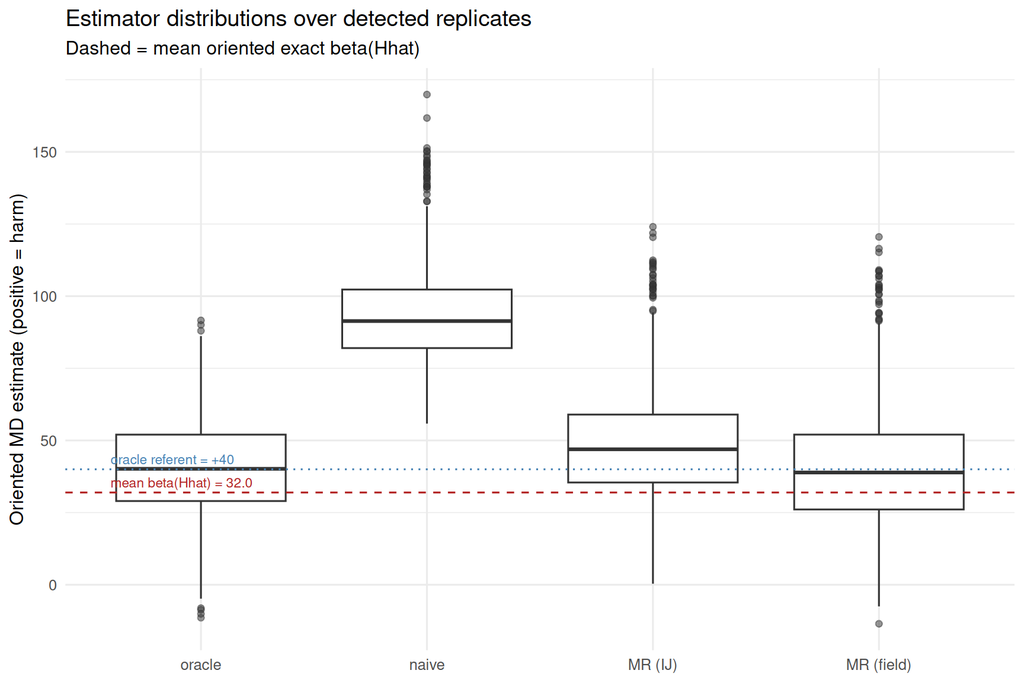

```r
if (nrow(rd)) {
  keys <- est_keys_for("H")
  long <- do.call(rbind, lapply(names(keys), function(lab)
    data.frame(Estimator = lab, est = .est_cols("H", keys[[lab]])$e)))
  long$Estimator <- factor(long$Estimator, levels = names(keys))
  bH_mean <- .mfin(rd$bH_or)
  p <- ggplot(long[is.finite(long$est), ], aes(x = Estimator, y = est)) +
    geom_boxplot(outlier.alpha = 0.5) +
    geom_hline(yintercept = bH_mean, linetype = 2, colour = "firebrick") +
    annotate("text", x = 0.6, y = bH_mean, vjust = -0.5, hjust = 0, size = 3,
             colour = "firebrick", label = sprintf("mean beta(Hhat) = %.1f", bH_mean)) +
    labs(y = "Oriented MD estimate (positive = harm)", x = NULL,
         title = "Estimator distributions over detected replicates",
         subtitle = "Dashed = mean oriented exact beta(Hhat)") +
    theme_minimal(base_size = 12)
  if (is.finite(oracle_ref))
    p <- p + geom_hline(yintercept = oracle_ref, linetype = 3, colour = "steelblue") +
      annotate("text", x = 0.6, y = oracle_ref, vjust = -0.5, hjust = 0, size = 3,
               colour = "steelblue", label = sprintf("oracle referent = %+.0f", oracle_ref))
  p
}
```

# 7 MR (field) diagnostics

```r
# Coverage with Wilson intervals against all four targets, two-sided (primary
# per the estimator's own interval) and one-sided on the exposed side.
if (nrow(rd) && any(is.finite(rd$fld_H_est2))) {
  cov_rows <- function(sfx) {
    b <- .blk[[sfx]]; keys <- est_keys_for(sfx)
    side <- if (sfx == "H") "lower" else "upper"
    tgt <- list(oracle = rd[[b$or_col]], betaHhat = rd[[b$beta]], structural = b$struct, fitted = b$marg)
    do.call(rbind, lapply(names(keys), function(lab) {
      ec <- .est_cols(sfx, keys[[lab]]); b1 <- .bound_of(sfx, keys[[lab]], side)
      do.call(rbind, lapply(names(tgt), function(tn) {
        c2 <- .cov_n(tgt[[tn]], ec$lo, ec$hi); w <- .wilson(c2[1], c2[2])
        c1 <- .cov1_n(tgt[[tn]], b1, side); w1 <- .wilson(c1[1], c1[2])
        data.frame(Block = if (sfx == "H") "Harm Hhat" else "Complement Hhat^c",
                   Estimator = lab, Target = tn, n = as.integer(c2[2]),
                   Cov2s = c2[1], W2_lo = w[1], W2_hi = w[2],
                   Cov1s = c1[1], W1_lo = w1[1], W1_hi = w1[2], Side = side,
                   stringsAsFactors = FALSE)
      }))
    }))
  }
  gt(rbind(cov_rows("H"), cov_rows("Hc")), groupname_col = "Block") |>
    tab_header(title = "95% coverage with Wilson intervals (two-sided; one-sided on the exposed side)",
               subtitle = "Targets: per-replicate oracle; beta(Hhat) (conditional, primary); structural; fitted") |>
    fmt_number(columns = c(Cov2s, W2_lo, W2_hi, Cov1s, W1_lo, W1_hi), decimals = 3) |>
    cols_label(Cov2s = "2-sided", W2_lo = "Wilson lo", W2_hi = "Wilson hi",
               Cov1s = "1-sided", W1_lo = "Wilson lo", W1_hi = "Wilson hi", Side = "1-sided bound")
}
```

95% coverage with Wilson intervals (two-sided; one-sided on the exposed side)

Targets: per-replicate oracle; beta(Hhat) (conditional, primary); structural; fitted

| Estimator | Target | n | 2-sided | Wilson lo | Wilson hi | 1-sided | Wilson lo | Wilson hi | 1-sided bound |
| --- | --- | --- | --- | --- | --- | --- | --- | --- | --- |
| Harm Hhat |  |  |  |  |  |  |  |  |  |
| oracle | oracle | 999 | 1.000 | 0.996 | 1.000 | 1.000 | 0.996 | 1.000 | lower |
| oracle | betaHhat | 999 | 0.925 | 0.907 | 0.940 | 0.882 | 0.860 | 0.900 | lower |
| oracle | structural | 999 | 0.951 | 0.936 | 0.963 | 0.943 | 0.927 | 0.956 | lower |
| oracle | fitted | 999 | 0.938 | 0.921 | 0.951 | 0.906 | 0.886 | 0.922 | lower |
| naive | oracle | 999 | 0.436 | 0.406 | 0.467 | 0.254 | 0.228 | 0.282 | lower |
| naive | betaHhat | 999 | 0.188 | 0.165 | 0.214 | 0.071 | 0.057 | 0.089 | lower |
| naive | structural | 999 | 0.388 | 0.359 | 0.419 | 0.200 | 0.177 | 0.226 | lower |
| naive | fitted | 999 | 0.271 | 0.245 | 0.300 | 0.114 | 0.096 | 0.135 | lower |
| MR (IJ) | oracle | 999 | 0.994 | 0.987 | 0.997 | 0.976 | 0.965 | 0.984 | lower |
| MR (IJ) | betaHhat | 999 | 0.982 | 0.972 | 0.989 | 0.953 | 0.938 | 0.964 | lower |
| MR (IJ) | structural | 999 | 0.992 | 0.984 | 0.996 | 0.982 | 0.972 | 0.989 | lower |
| MR (IJ) | fitted | 999 | 0.990 | 0.982 | 0.995 | 0.968 | 0.955 | 0.977 | lower |
| MR (field) | oracle | 999 | 0.964 | 0.951 | 0.974 | 0.956 | 0.941 | 0.967 | lower |
| MR (field) | betaHhat | 999 | 0.958 | 0.944 | 0.969 | 0.928 | 0.910 | 0.942 | lower |
| MR (field) | structural | 999 | 0.971 | 0.959 | 0.980 | 0.957 | 0.943 | 0.968 | lower |
| MR (field) | fitted | 999 | 0.970 | 0.957 | 0.979 | 0.943 | 0.927 | 0.956 | lower |
| Complement Hhat^c |  |  |  |  |  |  |  |  |  |
| oracle | oracle | 999 | 1.000 | 0.996 | 1.000 | 1.000 | 0.996 | 1.000 | upper |
| oracle | betaHhat | 999 | 0.949 | 0.933 | 0.961 | 0.910 | 0.891 | 0.926 | upper |
| oracle | structural | 999 | 0.953 | 0.938 | 0.964 | 0.962 | 0.948 | 0.972 | upper |
| oracle | fitted | 999 | 0.952 | 0.937 | 0.964 | 0.979 | 0.968 | 0.986 | upper |
| naive | oracle | 999 | 0.961 | 0.947 | 0.971 | 0.926 | 0.908 | 0.941 | upper |
| naive | betaHhat | 999 | 0.834 | 0.809 | 0.856 | 0.738 | 0.710 | 0.764 | upper |
| naive | structural | 999 | 0.924 | 0.906 | 0.939 | 0.858 | 0.835 | 0.878 | upper |
| naive | fitted | 999 | 0.959 | 0.945 | 0.970 | 0.935 | 0.918 | 0.949 | upper |
| MR (IJ) | oracle | 999 | 1.000 | 0.996 | 1.000 | 1.000 | 0.996 | 1.000 | upper |
| MR (IJ) | betaHhat | 999 | 1.000 | 0.996 | 1.000 | 0.997 | 0.991 | 0.999 | upper |
| MR (IJ) | structural | 999 | 0.999 | 0.994 | 1.000 | 1.000 | 0.996 | 1.000 | upper |
| MR (IJ) | fitted | 999 | 0.998 | 0.993 | 0.999 | 1.000 | 0.996 | 1.000 | upper |
| MR (field) | oracle | 999 | 0.990 | 0.982 | 0.995 | 0.990 | 0.982 | 0.995 | upper |
| MR (field) | betaHhat | 999 | 0.952 | 0.937 | 0.964 | 0.935 | 0.918 | 0.949 | upper |
| MR (field) | structural | 999 | 0.950 | 0.935 | 0.962 | 0.980 | 0.969 | 0.987 | upper |
| MR (field) | fitted | 999 | 0.909 | 0.889 | 0.925 | 0.989 | 0.980 | 0.994 | upper |

```
Table: Bias vs coverage, harm block (identity scale): bias_log = retained bias vs beta(Hhat) in MD units; b = bias / empirical SD, r = mean SE / empirical SD; *_ref = Gaussian bookkeeping prediction at (b, r).

|cell         |estimator |   n| bias_log| sd_emp| se_mean|     b|     r|  cov1|  cov2| cov1_ref| cov2_ref|
|:------------|:---------|---:|--------:|------:|-------:|-----:|-----:|-----:|-----:|--------:|--------:|
|md=40, n=700 |mr        | 999|   16.692| 19.880|  31.201| 0.840| 1.570| 0.953| 0.982|    0.959|    0.987|
|md=40, n=700 |fld       | 999|    8.688| 21.354|  24.582| 0.407| 1.151| 0.928| 0.958|    0.931|    0.964|
```

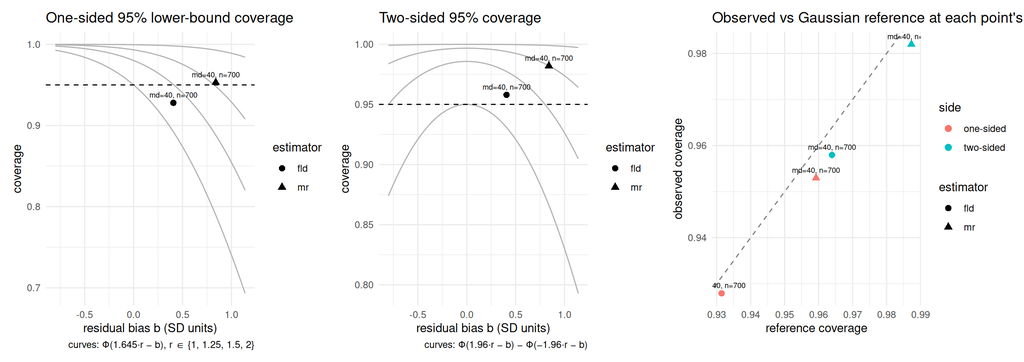

```r
# Bias-vs-coverage display for THIS cell on the IDENTITY scale
# (fs_sim_bias_coverage(scale = "identity"), the Mac task's R/ change): one
# point per estimator against the Gaussian bookkeeping reference.
if (nrow(rd) && any(is.finite(rd$fld_H_est2))) {
  .ests_H <- if (isTRUE(show_winner_rows) && any(is.finite(results$mr_H_se_w)))
    c("mr", "mr_w", "mr_wf", "fld") else c("mr", "fld")
  bc <- fs_sim_bias_coverage(res_or, block = "H", estimators = .ests_H, scale = "identity")
  bc$cell <- cell_lab
  print(knitr::kable(bc[, c("cell", "estimator", "n", "bias_log", "sd_emp", "se_mean", "b", "r",
                            "cov1", "cov2", "cov1_ref", "cov2_ref")], digits = 3,
    caption = "Bias vs coverage, harm block (identity scale): bias_log = retained bias vs beta(Hhat) in MD units; b = bias / empirical SD, r = mean SE / empirical SD; *_ref = Gaussian bookkeeping prediction at (b, r)."))
  print(fs_plot_bias_coverage(bc))
}
```

```r
if (nrow(rd) && any(is.finite(rd$fld_H_est2))) {
  ok <- is.finite(rd$bH_or)
  .ret <- function(est) {                        # retained bias vs beta(Hhat), MD units
    d <- est[ok] - rd$bH_or[ok]; d <- d[is.finite(d)]
    c(mean = mean(d), sd_est = stats::sd(d), n = length(d))
  }
  rb_nv <- .ret(rd$nv_H_est); rb_mr <- .ret(rd$mr_H_est); rb_fld <- .ret(rd$fld_H_est2)
  sd_emp_fld <- .sdfin(rd$fld_H_est2); sd_emp_mr <- .sdfin(rd$mr_H_est); sd_emp_nv <- .sdfin(rd$nv_H_est)
  lam_ratio <- .mfin(rd$fld_H_se) / sd_emp_fld
  ij_ratio  <- .mfin(rd$mr_H_se_ij) / sd_emp_mr
  # One-sided lower margins (MD units): field = mr_H_est - lo1s (about beta-tilde); IJ = 1.645 * se_ij.
  marg_fld <- .mfin(rd$mr_H_est - rd$fld_H_lo1s)
  marg_ij  <- .mfin(z95 * rd$mr_H_se_ij)
  hw_fld   <- .mfin((rd$fld_H_hi2s - rd$fld_H_lo2s) / 2)
  hw_ij    <- .mfin((rd$mr_H_hi - rd$mr_H_lo) / 2)
  print(knitr::kable(data.frame(
    quantity = c("naive retained bias vs beta(Hhat)  [MD]",
                 "MR (IJ) retained bias vs beta(Hhat)  [MD]",
                 "MR (field) est2 retained bias vs beta(Hhat)  [MD]",
                 "naive retained bias  [SD units]",
                 "MR (IJ) retained bias  [SD units]",
                 "MR (field) est2 retained bias  [SD units]",
                 "IJ SE / empirical SD  (MR (IJ))",
                 "lambda-SD / empirical SD  (MR (field))",
                 "one-sided LOWER margin, MD: MR (IJ)",
                 "one-sided LOWER margin, MD: MR (field)",
                 "two-sided half-width, MD: MR (IJ)",
                 "two-sided half-width, MD: MR (field)"),
    value = c(rb_nv["mean"], rb_mr["mean"], rb_fld["mean"],
              rb_nv["mean"] / sd_emp_nv, rb_mr["mean"] / sd_emp_mr, rb_fld["mean"] / sd_emp_fld,
              ij_ratio, lam_ratio, marg_ij, marg_fld, hw_ij, hw_fld),
    n = c(rb_nv["n"], rb_mr["n"], rb_fld["n"], rb_nv["n"], rb_mr["n"], rb_fld["n"], rep(NA, 6))),
    digits = 4,
    caption = "Harm block: retained bias against the conditional target beta(Hhat) (MD units and SD units), SE-calibration ratios, one-sided margins and half-widths."))
  print(knitr::kable(data.frame(
    metric = c("outer draws used (mean / min, of R_out = 1000)",
               "inner draws used per outer (mean, of R_in = 500)",
               "field block seconds (mean / median)",
               "replicates with a degenerate field (note set)"),
    value = c(sprintf("%.1f / %d", .mfin(rd$fld_H_nout), suppressWarnings(min(rd$fld_H_nout, na.rm = TRUE))),
              sprintf("%.1f", .mfin(rd$fld_H_nin_mean)),
              sprintf("%.2f / %.2f", .mfin(rd$fld_H_secs), .medfin(rd$fld_H_secs)),
              sprintf("%d of %d detected", sum(!is.na(rd$fld_H_note)), nrow(rd)))),
    caption = "MR (field) Monte Carlo draw usage and cost (detected replicates)."))
}
```

```
Table: Harm block: retained bias against the conditional target beta(Hhat) (MD units and SD units), SE-calibration ratios, one-sided margins and half-widths.

|quantity                                          |   value|   n|
|:-------------------------------------------------|-------:|---:|
|naive retained bias vs beta(Hhat)  [MD]           | 61.5297| 999|
|MR (IJ) retained bias vs beta(Hhat)  [MD]         | 16.6923| 999|
|MR (field) est2 retained bias vs beta(Hhat)  [MD] |  8.6877| 999|
|naive retained bias  [SD units]                   |  3.5727| 999|
|MR (IJ) retained bias  [SD units]                 |  0.8397| 999|
|MR (field) est2 retained bias  [SD units]         |  0.4068| 999|
|IJ SE / empirical SD  (MR (IJ))                   |  1.5695|  NA|
|lambda-SD / empirical SD  (MR (field))            |  1.1512|  NA|
|one-sided LOWER margin, MD: MR (IJ)               | 51.3214|  NA|
|one-sided LOWER margin, MD: MR (field)            | 50.3220|  NA|
|two-sided half-width, MD: MR (IJ)                 | 61.1532|  NA|
|two-sided half-width, MD: MR (field)              | 48.1732|  NA|


Table: MR (field) Monte Carlo draw usage and cost (detected replicates).

|metric                                           |value             |
|:------------------------------------------------|:-----------------|
|outer draws used (mean / min, of R_out = 1000)   |1000.0 / 997      |
|inner draws used per outer (mean, of R_in = 500) |500.0             |
|field block seconds (mean / median)              |42.30 / 42.88     |
|replicates with a degenerate field (note set)    |0 of 999 detected |
```

```r
# Regime diagnostic: p-hat(Hhat), the winner's own re-selection frequency
# (near 1 = settled selection; below ~0.5 = tie regime), and the modal
# candidates across replicates.
if (nrow(rd) && any(is.finite(rd$p_hat_H))) {
  ph <- rd$p_hat_H[is.finite(rd$p_hat_H)]
  print(knitr::kable(data.frame(
    metric = c("mean p-hat(Hhat)", "median p-hat(Hhat)", "share p-hat(Hhat) < 0.5 (tie regime)",
               "share p-hat(Hhat) >= 0.9 (settled)", "mean top-1 p-hat",
               "share of replicates where the winner IS the modal candidate"),
    value = c(mean(ph), stats::median(ph), mean(ph < 0.5), mean(ph >= 0.9),
              .mfin(rd$p_top1), mean(rd$p_hat_H == rd$p_top1, na.rm = TRUE))), digits = 3,
    caption = "Re-selection frequencies (return_reselection = TRUE), detected replicates."))
  print(knitr::kable(data.frame(p_hat_bin = cut(ph, c(0, .25, .5, .75, .9, 1), include.lowest = TRUE)) |>
          table() |> as.data.frame() |> setNames(c("p_hat(Hhat) bin", "n")),
        caption = "Distribution of p-hat(Hhat)."))
}
```

```
Table: Re-selection frequencies (return_reselection = TRUE), detected replicates.

|metric                                                      | value|
|:-----------------------------------------------------------|-----:|
|mean p-hat(Hhat)                                            | 0.082|
|median p-hat(Hhat)                                          | 0.065|
|share p-hat(Hhat) < 0.5 (tie regime)                        | 0.999|
|share p-hat(Hhat) >= 0.9 (settled)                          | 0.000|
|mean top-1 p-hat                                            | 0.103|
|share of replicates where the winner IS the modal candidate | 0.438|


Table: Distribution of p-hat(Hhat).

|p_hat(Hhat) bin |   n|
|:---------------|---:|
|[0,0.25]        | 981|
|(0.25,0.5]      |  17|
|(0.5,0.75]      |   1|
|(0.75,0.9]      |   0|
|(0.9,1]         |   0|
```

```r
# Complement field block: retained bias against beta(Hhat^c) (MD and SD units),
# the complement's lambda-SD/SD and IJ-SE/SD, the one-sided UPPER margins and
# half-widths beside IJ's, the regime diagnostics SD(beta-tilde^c)/naive SE and
# lambda-SD^c/naive SE, and the complement-fit accounting and cost.
if (nrow(rd) && any(is.finite(rd$fld_Hc_est2))) {
  okc <- is.finite(rd$bHc_or)
  .retc <- function(est) { d <- est[okc] - rd$bHc_or[okc]; d <- d[is.finite(d)]
    c(mean = mean(d), sd_est = stats::sd(d), n = length(d)) }
  rbc_nv <- .retc(rd$nv_Hc_est); rbc_mr <- .retc(rd$mr_Hc_est); rbc_fld <- .retc(rd$fld_Hc_est2)
  sdc_fld <- .sdfin(rd$fld_Hc_est2); sdc_mr <- .sdfin(rd$mr_Hc_est); sdc_nv <- .sdfin(rd$nv_Hc_est)
  nv_se_c <- .mfin(rd$nv_Hc_se)
  print(knitr::kable(data.frame(
    quantity = c("naive retained bias vs beta(Hhat^c)  [MD]",
                 "MR (IJ) retained bias vs beta(Hhat^c)  [MD]",
                 "MR (field) est2 retained bias vs beta(Hhat^c)  [MD]",
                 "naive retained bias  [SD units]",
                 "MR (IJ) retained bias  [SD units]",
                 "MR (field) est2 retained bias  [SD units]",
                 "IJ SE / empirical SD  (MR (IJ), complement)",
                 "lambda-SD / empirical SD  (MR (field), complement)",
                 "REGIME: SD(beta-tilde^c) / naive SE",
                 "REGIME: lambda-SD^c / naive SE",
                 "one-sided UPPER margin, MD: MR (IJ)",
                 "one-sided UPPER margin, MD: MR (field)",
                 "two-sided half-width, MD: MR (IJ)",
                 "two-sided half-width, MD: MR (field)"),
    value = c(rbc_nv["mean"], rbc_mr["mean"], rbc_fld["mean"],
              rbc_nv["mean"] / sdc_nv, rbc_mr["mean"] / sdc_mr, rbc_fld["mean"] / sdc_fld,
              .mfin(rd$mr_Hc_se_ij) / sdc_mr, .mfin(rd$fld_Hc_se) / sdc_fld,
              sdc_mr / nv_se_c, .mfin(rd$fld_Hc_se) / nv_se_c,
              .mfin(z95 * rd$mr_Hc_se_ij), .mfin(rd$fld_Hc_up1s - rd$mr_Hc_est),
              .mfin((rd$mr_Hc_hi - rd$mr_Hc_lo) / 2), .mfin((rd$fld_Hc_hi2s - rd$fld_Hc_lo2s) / 2)),
    n = c(rbc_nv["n"], rbc_mr["n"], rbc_fld["n"], rbc_nv["n"], rbc_mr["n"], rbc_fld["n"], rep(NA, 8))),
    digits = 4,
    caption = "Complement Hhat^c: retained bias against beta(Hhat^c), SE-calibration ratios, regime diagnostics, one-sided upper margins and half-widths (MD units)."))
  print(knitr::kable(data.frame(
    metric = c("outer draws used (mean / min, of R_out = 1000)",
               "inner draws used per outer (mean, of R_in = 500)",
               "distinct complement fits per replicate (mean / max)",
               "share of draw-winner readings needing a new complement fit (mean / max)",
               "complement field block seconds (mean / median)",
               "replicates with a degenerate complement field (note set)"),
    value = c(sprintf("%.1f / %d", .mfin(rd$fld_Hc_nout), suppressWarnings(min(rd$fld_Hc_nout, na.rm = TRUE))),
              sprintf("%.1f", .mfin(rd$fld_Hc_nin_mean)),
              sprintf("%.1f / %d", .mfin(rd$fld_Hc_nfit), suppressWarnings(max(rd$fld_Hc_nfit, na.rm = TRUE))),
              sprintf("%.3f / %.3f", .mfin(rd$fld_Hc_share_newfit), suppressWarnings(max(rd$fld_Hc_share_newfit, na.rm = TRUE))),
              sprintf("%.2f / %.2f", .mfin(rd$fld_Hc_secs), .medfin(rd$fld_Hc_secs)),
              sprintf("%d of %d detected", sum(!is.na(rd$fld_Hc_note)), nrow(rd)))),
    caption = "Complement field: Monte Carlo draw usage, complement-fit accounting and cost (detected replicates)."))
}
```

```
Table: Complement Hhat^c: retained bias against beta(Hhat^c), SE-calibration ratios, regime diagnostics, one-sided upper margins and half-widths (MD units).

|quantity                                            |    value|   n|
|:---------------------------------------------------|--------:|---:|
|naive retained bias vs beta(Hhat^c)  [MD]           | -11.3093| 999|
|MR (IJ) retained bias vs beta(Hhat^c)  [MD]         |  -3.4984| 999|
|MR (field) est2 retained bias vs beta(Hhat^c)  [MD] |  -1.8992| 999|
|naive retained bias  [SD units]                     |  -1.1278| 999|
|MR (IJ) retained bias  [SD units]                   |  -0.3404| 999|
|MR (field) est2 retained bias  [SD units]           |  -0.1821| 999|
|IJ SE / empirical SD  (MR (IJ), complement)         |   1.9383|  NA|
|lambda-SD / empirical SD  (MR (field), complement)  |   1.0181|  NA|
|REGIME: SD(beta-tilde^c) / naive SE                 |   0.9526|  NA|
|REGIME: lambda-SD^c / naive SE                      |   0.9843|  NA|
|one-sided UPPER margin, MD: MR (IJ)                 |  32.7696|  NA|
|one-sided UPPER margin, MD: MR (field)              |  19.0589|  NA|
|two-sided half-width, MD: MR (IJ)                   |  39.0473|  NA|
|two-sided half-width, MD: MR (field)                |  20.7232|  NA|


Table: Complement field: Monte Carlo draw usage, complement-fit accounting and cost (detected replicates).

|metric                                                                  |value             |
|:-----------------------------------------------------------------------|:-----------------|
|outer draws used (mean / min, of R_out = 1000)                          |1000.0 / 997      |
|inner draws used per outer (mean, of R_in = 500)                        |500.0             |
|distinct complement fits per replicate (mean / max)                     |1087.2 / 1442     |
|share of draw-winner readings needing a new complement fit (mean / max) |0.079 / 0.216     |
|complement field block seconds (mean / median)                          |5.80 / 5.90       |
|replicates with a degenerate complement field (note set)                |0 of 999 detected |
```

```
Table: Bias vs coverage, complement block (one-sided = UPPER bound; identity scale): bias_log = retained bias vs beta(Hhat^c) in MD units; b, r as above; *_ref = Gaussian bookkeeping prediction at (b, r).

|cell         |estimator |   n| bias_log| sd_emp| se_mean|      b|     r|  cov1|  cov2| cov1_ref| cov2_ref|
|:------------|:---------|---:|--------:|------:|-------:|------:|-----:|-----:|-----:|--------:|--------:|
|md=40, n=700 |mr        | 999|   -3.498| 10.278|  19.922| -0.340| 1.938| 0.997| 1.000|    0.998|     1.00|
|md=40, n=700 |fld       | 999|   -1.899| 10.431|  10.620| -0.182| 1.018| 0.935| 0.952|    0.932|     0.95|
```

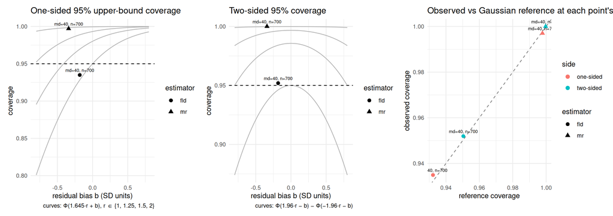

```r
# Complement display (block Hc, side upper, identity scale): one point per
# estimator against the Gaussian reference Phi(1.645 r + b) for the UPPER bound.
if (nrow(rd) && any(is.finite(rd$fld_Hc_est2))) {
  .ests_Hc <- if (isTRUE(show_winner_rows) && any(is.finite(results$mr_Hc_se_w)))
    c("mr", "mr_w", "mr_wf", "fld") else c("mr", "fld")
  bcc <- fs_sim_bias_coverage(res_or, block = "Hc", estimators = .ests_Hc, side = "upper", scale = "identity")
  bcc$cell <- cell_lab
  print(knitr::kable(bcc[, c("cell", "estimator", "n", "bias_log", "sd_emp", "se_mean", "b", "r",
                             "cov1", "cov2", "cov1_ref", "cov2_ref")], digits = 3,
    caption = "Bias vs coverage, complement block (one-sided = UPPER bound; identity scale): bias_log = retained bias vs beta(Hhat^c) in MD units; b, r as above; *_ref = Gaussian bookkeeping prediction at (b, r)."))
  print(fs_plot_bias_coverage(bcc, side = "upper"))
}
```

```r
# Simultaneous (H lower, Hc upper) pair: joint coverage of
# (beta(Hhat) >= lower_H AND beta(Hhat^c) <= upper_Hc) for (i) the separate 95%
# field bounds, (ii) the Bonferroni pair, (iii) the calibrated pair; margins
# in MD units from the two-term de-biased estimates.
if (nrow(rd) && any(is.finite(rd$fld_joint_gamma))) {
  rJ <- rd[is.finite(rd$bH_or) & is.finite(rd$bHc_or) & is.finite(rd$fld_joint_gamma), , drop = FALSE]
  .wl <- function(x, n) { w <- .wilson(x, n); sprintf("%.3f (%.3f, %.3f)", x, w[1], w[2]) }
  pairs <- list(
    `separate 95% field bounds` = list(lo = rJ$fld_H_lo1s, up = rJ$fld_Hc_up1s),
    `Bonferroni (gamma = 0.025)` = list(lo = rJ$fld_joint_bonf_loH, up = rJ$fld_joint_bonf_upHc),
    `calibrated gamma`           = list(lo = rJ$fld_joint_loH, up = rJ$fld_joint_upHc))
  jt <- do.call(rbind, lapply(names(pairs), function(nm) {
    p <- pairs[[nm]]
    covH <- rJ$bH_or >= p$lo; covC <- rJ$bHc_or <= p$up
    data.frame(pair = nm, n = nrow(rJ), joint_cov = .wl(mean(covH & covC), nrow(rJ)),
               cov_H = mean(covH), cov_Hc = mean(covC),
               margin_H = mean(rJ$mr_H_est - p$lo), margin_Hc = mean(p$up - rJ$mr_Hc_est),
               stringsAsFactors = FALSE)
  }))
  print(knitr::kable(jt, digits = 3,
    caption = sprintf("Joint (Hhat lower, Hhat^c upper) coverage of (beta(Hhat), beta(Hhat^c)) with Wilson intervals; margins in MD units from the two-term de-biased estimates. Mean gamma = %.4f (achieved joint prob. %.3f; Bonferroni %.3f); mean corr(Lambda*, Lambda*c) = %+.3f; n_joint_draws mean %.0f.",
                      mean(rJ$fld_joint_gamma), mean(rJ$fld_joint_prob), mean(rJ$fld_joint_bonf_prob),
                      mean(rJ$fld_joint_corr), mean(rJ$fld_joint_n))))
}
```

```
Table: Joint (Hhat lower, Hhat^c upper) coverage of (beta(Hhat), beta(Hhat^c)) with Wilson intervals; margins in MD units from the two-term de-biased estimates. Mean gamma = 0.0251 (achieved joint prob. 0.950; Bonferroni 0.951); mean corr(Lambda*, Lambda*c) = +0.090; n_joint_draws mean 1000.

|pair                       |   n|joint_cov            | cov_H| cov_Hc| margin_H| margin_Hc|
|:--------------------------|---:|:--------------------|-----:|------:|--------:|---------:|
|separate 95% field bounds  | 999|0.865 (0.842, 0.885) | 0.928|  0.935|   50.322|    19.059|
|Bonferroni (gamma = 0.025) | 999|0.929 (0.911, 0.943) | 0.959|  0.969|   59.935|    22.412|
|calibrated gamma           | 999|0.929 (0.911, 0.943) | 0.959|  0.969|   59.867|    22.392|
```

# 8 Identification

```r
if (nrow(rd)) {
  knitr::kable(data.frame(
    metric = c("sens", "spec", "ppv", "npv"),
    mean   = c(.mfin(rd$sens), .mfin(rd$spec), .mfin(rd$ppv), .mfin(rd$npv)),
    median = c(.medfin(rd$sens), .medfin(rd$spec), .medfin(rd$ppv), .medfin(rd$npv))),
    digits = 3, caption = "Classification of the identified subgroup vs the true harm flag (detected reps).")
}
```

Classification of the identified subgroup vs the true harm flag (detected reps).

| metric | mean | median |
| --- | --- | --- |
| sens | 0.209 | 0.191 |
| spec | 0.852 | 0.858 |
| ppv | 0.417 | 0.397 |
| npv | 0.672 | 0.667 |

### 8.0.1 Identification structure

```r
# Same package engine as the survival template and the twin
# (fs_identification_summary()).  The triple: true-region covariates age
# (anchor) and preanti (partner), with str2 the BINARY coarsening of preanti as
# the proxy (meaningful only while include_str2 is TRUE).
id_run <- fs_identification_summary(
  bundles = stats::setNames(list(results), as.character(n_sample)),
  anchor  = "age", partner = "preanti", proxy = "str2",
  confounders = confounders_analysis, sweep_label = "Trial size (n)")
id_run
```

```
<fs_identification>
  triple : anchor = age | partner = preanti | proxy = str2
  sweep  : 700
  700      detection 99.9% of 1000; anchor recovered 44.4%
```

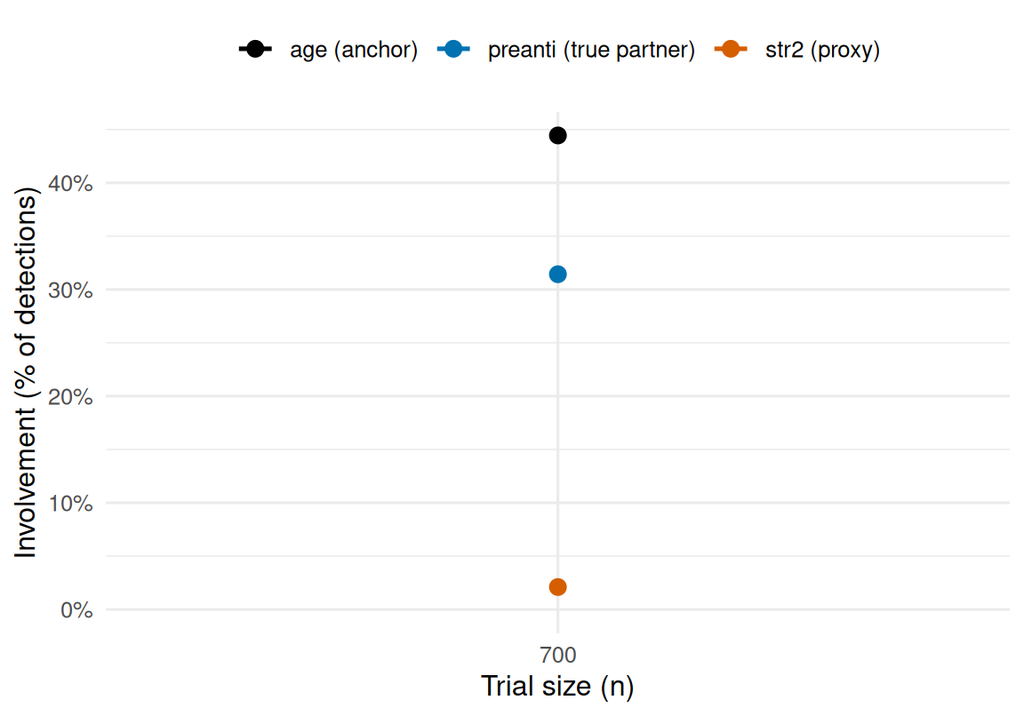

```r
plot_fs_identification_involvement(id_run)
```

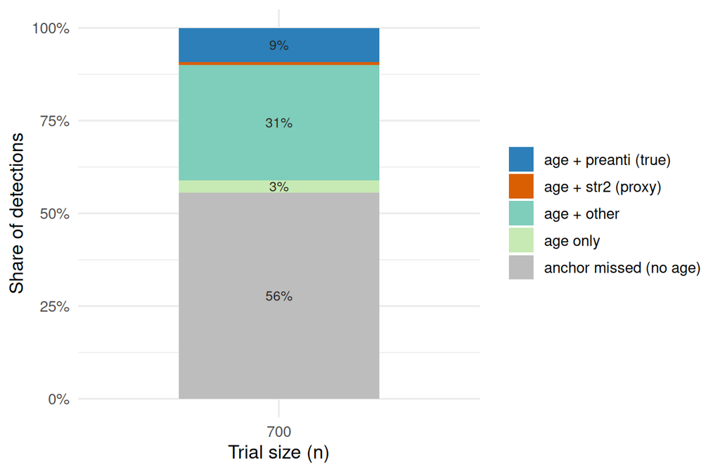

```r
plot_fs_identification_structure(id_run)
```

```r
fs_identification_table(id_run, as_gt = TRUE)
```

Identification structure across the sweep

anchor age | true partner preanti | proxy str2

| Quantity | 700 |
| --- | --- |
| Detection rate (all replicates) | 99.9% |
| age + preanti (true partner) | 9.2% |
| age + str2 (proxy partner) | 0.8% |
| age + other factor | 31.0% |
| age only | 3.4% |
| anchor missed (no age) | 55.6% |
| Anchor recovered (age, any pairing) | 44.4% |
| Conditional partner split, preanti : str2 | 92 : 8 |

Classification of the identified subgroup against the planted membership, averaged over detections (700): sensitivity 0.21, specificity 0.85, PPV 0.42, NPV 0.67.

### 8.0.2 Selected-covariate frequencies and realized rules

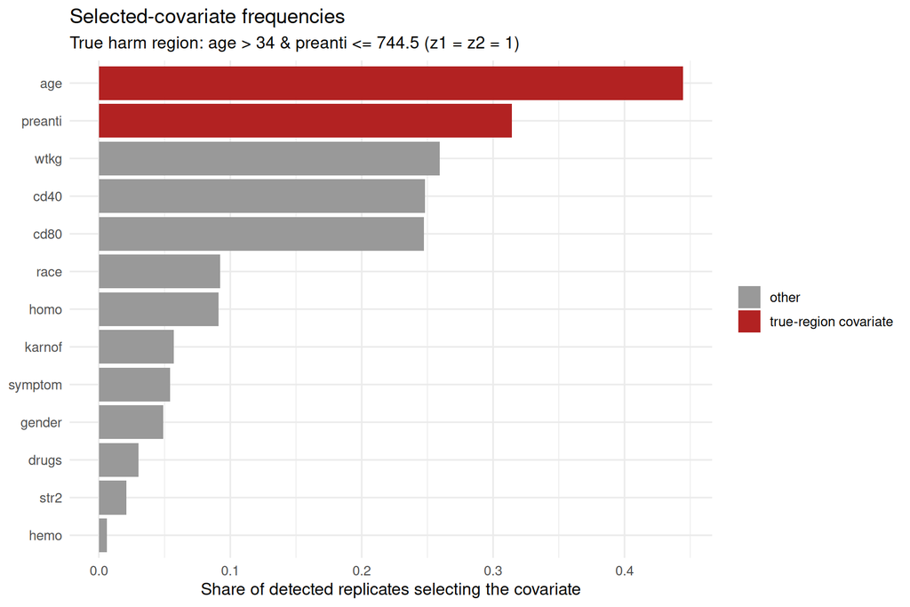

Realized rules (sg_def) by frequency, detected reps.

| rule | n | share |
| --- | --- | --- |
| !{homo} & !{age <= 33} | 4 | 0.004 |
| {symptom} & !{age <= 30} | 4 | 0.004 |
| !{age <= 33} & {age <= 38} | 3 | 0.003 |
| !{age <= 35} & {age <= 39} | 3 | 0.003 |
| !{gender} | 3 | 0.003 |
| !{homo} & {race} | 3 | 0.003 |
| !{race} & !{homo} | 3 | 0.003 |
| {drugs} | 3 | 0.003 |
| !{age <= 33} & {age <= 35} | 2 | 0.002 |
| !{age <= 37} & !{wtkg <= 74} | 2 | 0.002 |
| !{age <= 38} & {karnof <= 95} | 2 | 0.002 |
| !{age <= 39} & !{wtkg <= 75} | 2 | 0.002 |
| !{age <= 39} & {homo} | 2 | 0.002 |
| !{age <= 39} & {preanti <= 0} | 2 | 0.002 |
| !{cd40 <= 344} & !{homo} | 2 | 0.002 |
| !{cd80 <= 892} & !{homo} | 2 | 0.002 |
| !{drugs} & !{age <= 42} | 2 | 0.002 |
| !{gender} & !{age <= 30} | 2 | 0.002 |
| !{gender} & !{age <= 31} | 2 | 0.002 |
| !{gender} & {wtkg <= 82} | 2 | 0.002 |
| !{homo} & !{age <= 35} | 2 | 0.002 |
| !{homo} & !{str2} | 2 | 0.002 |
| !{homo} & {age <= 30} | 2 | 0.002 |
| !{homo} & {karnof <= 90} | 2 | 0.002 |
| !{race} & {age <= 28} | 2 | 0.002 |
| !{wtkg <= 66} & {race} | 2 | 0.002 |
| !{wtkg <= 83} & !{preanti <= 0} | 2 | 0.002 |
| {age <= 25} | 2 | 0.002 |
| {age <= 26} | 2 | 0.002 |
| {drugs} & {age <= 42} | 2 | 0.002 |

[output cut: 912 more lines]

```r
if (nrow(rd)) {
  rule_covs <- function(rule) forestsearch:::.fs_rule_columns(rule)
  cov_list  <- lapply(rd$sg_def, rule_covs)
  cov_all   <- unique(unlist(cov_list))
  if (length(cov_all)) {
    cf <- vapply(cov_all, function(v)
      mean(vapply(cov_list, function(x) v %in% x, logical(1))), numeric(1))
    cf_df <- data.frame(covariate = names(cf), share = unname(cf))
    cf_df$true_region <- cf_df$covariate %in% c("age", "preanti")
    print(
      ggplot(cf_df, aes(x = reorder(covariate, share), y = share, fill = true_region)) +
        geom_col() + coord_flip() +
        scale_fill_manual(values = c(`TRUE` = "firebrick", `FALSE` = "grey60"),
                          labels = c(`TRUE` = "true-region covariate", `FALSE` = "other"), name = NULL) +
        labs(x = NULL, y = "Share of detected replicates selecting the covariate",
             title = "Selected-covariate frequencies",
             subtitle = "True harm region: age > 34 & preanti <= 744.5 (z1 = z2 = 1)") +
        theme_minimal(base_size = 12))
    rules <- sort(table(rd$sg_def), decreasing = TRUE)
    knitr::kable(data.frame(rule = names(rules), n = as.integer(rules),
                            share = as.numeric(rules) / nrow(rd)),
      digits = 3, caption = "Realized rules (sg_def) by frequency, detected reps.")
  }
}
```

# 9 Timing

```r
.dist_row <- function(x) {
  x <- x[is.finite(x)]
  if (!length(x)) return(rep(NA_real_, 14))
  c(min = min(x), stats::quantile(x, probs = seq(0.1, 0.9, 0.1)),
    median = stats::median(x), mean = mean(x), max = max(x), n = length(x))
}
tim <- rbind(fit_mr_secs = .dist_row(results$fit_mr_secs),
             fld_H_secs  = .dist_row(results$fld_H_secs),
             fld_Hc_secs = .dist_row(results$fld_Hc_secs))
knitr::kable(tim, digits = 2,
  caption = sprintf("Per-replicate seconds (all replicates; %s mode, %d workers). fit_mr_secs INCLUDES the field blocks.",
                    parallel_mode, n_workers))
```

Per-replicate seconds (all replicates; sims mode, 63 workers). fit_mr_secs INCLUDES the field blocks.

|  | min | 10% | 20% | 30% | 40% | 50% | 60% | 70% | 80% | 90% | median | mean | max | n |
| --- | --- | --- | --- | --- | --- | --- | --- | --- | --- | --- | --- | --- | --- | --- |
| fit_mr_secs | 1.27 | 67.35 | 75.26 | 80.63 | 84.45 | 87.40 | 90.44 | 93.34 | 96.33 | 100.46 | 87.40 | 85.45 | 113.35 | 1000 |
| fld_H_secs | 20.89 | 34.50 | 38.09 | 40.16 | 41.70 | 42.88 | 44.43 | 45.61 | 47.19 | 49.25 | 42.88 | 42.30 | 56.76 | 999 |
| fld_Hc_secs | 2.62 | 4.08 | 4.65 | 5.12 | 5.57 | 5.90 | 6.22 | 6.54 | 6.85 | 7.38 | 5.90 | 5.80 | 9.12 | 999 |

```r
# Scale-up projection: measured per-replicate cost drives a busiest-worker wall
# model, calibrated by k = measured wall / modelled wall on THIS run.
mr_mean <- .mfin(results$fit_mr_secs)
fmt_hm <- function(sec) {
  if (!is.finite(sec)) return("-")
  h <- floor(sec / 3600); m <- round((sec - 3600 * h) / 60)
  if (h >= 1) sprintf("%d h %02d m", h, m) else sprintf("%d m", round(sec / 60))
}
wall_model <- function(ns) ceiling(ns / n_workers) * mr_mean
k_cal <- if (is.finite(elapsed) && wall_model(n_batch) > 0) elapsed / wall_model(n_batch) else NA_real_
proj <- do.call(rbind, lapply(c(n_batch, 1000L, 2000L), function(ns)
  data.frame(n_sims = ns, per_rep_s = round(mr_mean, 2), cpu_hours = round(ns * mr_mean / 3600, 2),
             wall_model = fmt_hm(wall_model(ns)),
             wall_calibrated = fmt_hm(if (is.finite(k_cal)) k_cal * wall_model(ns) else NA_real_))))
proj$wall_actual <- c(fmt_hm(elapsed), "-", "-")
cat(sprintf("This run: %d reps in %s on %d workers; per rep fit+MR(+field) %.2f s%s.\n",
            n_batch, if (is.finite(elapsed)) sprintf("%.0f s", elapsed) else "- (combine)", n_workers, mr_mean,
            if (is.finite(k_cal)) sprintf("; realized overhead factor k = %.2f", k_cal) else ""))
```

```
This run: 1000 reps in 1503 s on 63 workers; per rep fit+MR(+field) 85.45 s; realized overhead factor k = 1.10.
```

```r
knitr::kable(proj, caption = "Wall-clock projection: ceil(sims / workers) x per-rep cost, and k x that.")
```

Wall-clock projection: ceil(sims / workers) x per-rep cost, and k x that.

| n_sims | per_rep_s | cpu_hours | wall_model | wall_calibrated | wall_actual |
| --- | --- | --- | --- | --- | --- |
| 1000 | 85.45 | 23.73 | 23 m | 25 m | 25 m |
| 1000 | 85.45 | 23.73 | 23 m | 25 m | - |
| 2000 | 85.45 | 47.47 | 46 m | 50 m | - |

```r
.fmt_dur <- function(s) {
  h <- s %/% 3600; m <- (s %% 3600) %/% 60; sec <- round(s %% 60)
  if (h >= 1) sprintf("%d h %02d m %02d s", h, m, sec)
  else if (m >= 1) sprintf("%d m %02d s", m, sec)
  else sprintf("%.1f s", s)
}
.secs_total <- as.numeric(difftime(Sys.time(), .t0_doc, units = "secs"))
cat(sprintf("TOTAL wall-clock, start to finish: %s  (= %.0f s; %d reps on %d workers)\n",
            .fmt_dur(.secs_total), .secs_total, n_batch, n_workers))
```

```
TOTAL wall-clock, start to finish: 25 m 11 s  (= 1511 s; 1000 reps on 63 workers)
```

```r
if (is.finite(elapsed)) cat(sprintf("  of which the run loop: %s\n", .fmt_dur(elapsed)))
```

```
  of which the run loop: 25 m 03 s
```